# Initial Exploration of the P/NBD Model

Author

Mick Cooney mickcooney@gmail.com

Published

December 13, 2023

In this workbook we introduce the various different BTYD models, starting with a discussion of the underlying theory.

# 1 Background Theory

Before we start working on fitting and using the various Buy-Till-You-Die models, we first need to discuss the basic underlying theory and model.

In this model, we assume a customer becomes ‘alive’ to the business at the first purchase and then makes purchases stochastically but at a steady-rate for a period of time, and then ‘dies’ - i.e. becomes inactive to the business - hence the use of “Buy-Till-You-Die”.

Thus, at a high level these models decompose into modelling the transaction events using distributions such as the Poisson or Negative Binomial, and then modelling the ‘dropout’ process using some other method.

A number of BTYD models exist and for this workshop we will focus on the BG/NBD model - the Beta-Geometric Negative Binomial Distribution model (though we will discuss the P/NBD model also).

These models require only two pieces of information about each customer’s purchasing history: the “recency” (when the last transaction occurred) and “frequency” (the count of transactions made by that customer in a specified time period).

The notation used to represent this information is

$$X = (x, \, t_x, \, T),$$
where

$$\begin{eqnarray*}
x &=& \text{the number of transactions}, \\
T &=& \text{the observed time period}, \\
t_x &=& \text{the time since the last transaction}.
\end{eqnarray*}$$

From this summary data we can fit most BTYD models.

# 2 BTYD Models

There are a number of different statistical approaches to building BTYD models - relying on a number of different assumptions about how the various recency, frequency and monetary values are modelled.

We now discuss a number of different ways of modelling this.

## 2.1 Pareto/Negative-Binomial Distribution (P/NBD) Model

The P/NBD model relies on five assumptions:

1. While active, the number of transactions made by a customer follows a Poisson process with transaction rate $\lambda$.
2. Heterogeneity in $\lambda$ follows a Gamma distribution $\Gamma(\lambda \, | \, \alpha, r)$ with shape $r$ and rate $\alpha$.
3. Each customer has an unobserved ‘lifetime’ of length $\tau$. This point at which the customer becomes inactive is distributed as an exponential with dropout rate $\mu$.
4. Heterogeneity in dropout rates across customers follows a Gamma distribution $\Gamma(\mu \, | \, s, \beta)$ with shape parameter $s$ and rate parameter $\beta$.
5. The transaction rate $\lambda$ and the dropout rate $\mu$ vary independently across customers.

As before, we express this in mathematical notation as:

$$\begin{eqnarray*}
\lambda &\sim& \Gamma(\alpha, r), \\
\mu &\sim& \Gamma(s, \beta), \\
\tau &\sim& \text{Exponential}(\mu)
\end{eqnarray*}$$

## 2.2 Beta-Geometric/Negative-Binomial Distribution (BG/NBD) Model

This model relies on a number of base assumptions, somewhat similar to the P/NBD model but modelling lifetime with a different process:

1. While active, the number of transactions made by a customer follows a Poisson process with transaction rate $\lambda$.
2. Heterogeneity in $\lambda$ follows a Gamma distribution $\Gamma(\lambda \, | \, \alpha, r)$ with parameters shape $r$ and rate $\alpha$.
3. After any transaction, a customer becomes inactive with probability $p$.
4. Heterogeneity in $p$ follows a Beta distribution $B(p \, | \, a, b)$ with shape parameters $a$ and $b$.
5. The transaction rate $\lambda$ and the dropout probability $p$ vary independently across customers.

Note that it follows from the above assumptions that the probability of a customer being ‘alive’ after any transaction is given by the Geometric distribution, and hence the Beta-Geometric in the name.

To put this into more formal mathematical notation, we have:

$$\begin{eqnarray*}
\lambda &\sim& \Gamma(\alpha, r), \\
P(\text{alive}, k) &\sim& \text{Geometric}(p, k), \\
p &\sim& \text{Beta}(a, b)
\end{eqnarray*}$$

# 3 Initial P/NBD Models

We start by modelling the P/NBD model using our synthetic datasets before we try to model real-life data.

## 3.1 Load Short Time-frame Synthetic Data

We now want to load the short time-frame synthetic data.

```r
customer_cohortdata_tbl   <- read_rds("data/shortsynth_customer_cohort_data_tbl.rds")
customer_cohortdata_tbl   |> glimpse()
```

```
Rows: 5,000
Columns: 5
$ customer_id     <chr> "SFC202001_0001", "SFC202001_0002", "SFC202001_0003", …
$ cohort_qtr      <chr> "2020 Q1", "2020 Q1", "2020 Q1", "2020 Q1", "2020 Q1",…
$ cohort_ym       <chr> "2020 01", "2020 01", "2020 01", "2020 01", "2020 01",…
$ first_tnx_date  <dttm> 2020-01-01 15:26:03, 2020-01-01 08:00:48, 2020-01-01 …
$ total_tnx_count <int> 4, 5, 1, 1, 6, 1, 5, 5, 1, 2, 3, 11, 1, 5, 1, 1, 16, 1…
```

```r
customer_simparams_tbl    <- read_rds("data/rawsynthdata_shortframe_simparams_tbl.rds")
customer_simparams_tbl    |> glimpse()
```

```
Rows: 5,000
Columns: 9
$ customer_id     <chr> "SFC202001_0001", "SFC202001_0002", "SFC202001_0003", …
$ cohort_qtr      <chr> "2020 Q1", "2020 Q1", "2020 Q1", "2020 Q1", "2020 Q1",…
$ cohort_ym       <chr> "2020 01", "2020 01", "2020 01", "2020 01", "2020 01",…
$ first_tnx_date  <date> 2020-01-01, 2020-01-01, 2020-01-01, 2020-01-01, 2020-…
$ customer_lambda <dbl> 0.157090748, 0.448994723, 0.232671532, 0.081519299, 0.…
$ customer_mu     <dbl> 0.27598527, 0.11711379, 0.14782489, 0.25511925, 0.1080…
$ customer_tau    <dbl> 10.7782514, 14.8992436, 2.2100455, 2.5468701, 13.76583…
$ customer_amtmn  <dbl> 245.83640, 169.05146, 241.95005, 159.83793, 203.42676,…
$ customer_amtcv  <dbl> 0.5, 0.5, 0.5, 0.5, 0.5, 0.5, 0.5, 0.5, 0.5, 0.5, 0.5,…
```

```r
customer_id_lookup_tbl    <- read_rds("data/shortsynth_customer_id_lookup_tbl.rds")
customer_id_lookup_tbl    |> glimpse()
```

```
Rows: 5,000
Columns: 2
$ customer_id <fct> SFC202001_0002, SFC202001_0004, SFC202001_0001, SFC202001_…
$ orig_id     <chr> "SFC202001_0002", "SFC202001_0004", "SFC202001_0001", "SFC…
```

```r
customer_transactions_tbl <- read_rds("data/shortsynth_transaction_data_tbl.rds")
customer_transactions_tbl |> glimpse()
```

```
Rows: 29,504
Columns: 8
$ customer_id   <fct> SFC202001_0002, SFC202001_0004, SFC202001_0001, SFC20200…
$ tnx_timestamp <dttm> 2020-01-01 08:00:48, 2020-01-01 14:02:22, 2020-01-01 15…
$ tnx_dow       <fct> Wed, Wed, Wed, Wed, Thu, Thu, Thu, Thu, Thu, Thu, Fri, F…
$ tnx_month     <fct> Jan, Jan, Jan, Jan, Jan, Jan, Jan, Jan, Jan, Jan, Jan, J…
$ tnx_week      <chr> "00", "00", "00", "00", "00", "00", "00", "00", "00", "0…
$ invoice_id    <chr> "T20200101-0001", "T20200101-0002", "T20200101-0003", "T…
$ tnx_amount    <dbl> 120.46, 208.45, 386.80, 111.52, 133.66, 133.52, 26.19, 1…
$ orig_id       <chr> "SFC202001_0002", "SFC202001_0004", "SFC202001_0001", "S…
```

```r
customer_fit_stats_tbl    <- read_rds("data/shortsynth_customer_fit_stats_tbl.rds")
customer_fit_stats_tbl    |> glimpse()
```

```
Rows: 3,320
Columns: 6
$ customer_id    <fct> SFC202001_0002, SFC202001_0004, SFC202001_0001, SFC2020…
$ first_tnx_date <dttm> 2020-01-01 08:00:48, 2020-01-01 14:02:22, 2020-01-01 1…
$ last_tnx_date  <dttm> 2020-04-09 21:49:03, 2020-01-01 14:02:22, 2020-02-27 1…
$ x              <dbl> 4, 0, 3, 0, 0, 5, 1, 4, 4, 0, 0, 15, 0, 10, 4, 0, 2, 0,…
$ t_x            <dbl> 14.225024, 0.000000, 8.113130, 0.000000, 0.000000, 13.5…
$ T_cal          <dbl> 104.3809, 104.3450, 104.3367, 104.3152, 104.2409, 104.2…
```

```r
customer_valid_stats_tbl  <- read_rds("data/shortsynth_obs_validdata_tbl.rds")
customer_valid_stats_tbl  |> glimpse()
```

```
Rows: 3,320
Columns: 3
$ customer_id       <fct> SFC202001_0002, SFC202001_0004, SFC202001_0001, SFC2…
$ tnx_count         <dbl> 0, 0, 0, 0, 0, 0, 0, 0, 0, 0, 0, 0, 0, 0, 0, 0, 0, 0…
$ tnx_last_interval <dbl> NA, NA, NA, NA, NA, NA, NA, NA, NA, NA, NA, NA, NA, …
```

```r
obs_fitdata_tbl           <- read_rds("data/shortsynth_obs_fitdata_tbl.rds")
obs_fitdata_tbl           |> glimpse()
```

```
Rows: 3,320
Columns: 6
$ customer_id    <fct> SFC202001_0002, SFC202001_0004, SFC202001_0001, SFC2020…
$ first_tnx_date <dttm> 2020-01-01 08:00:48, 2020-01-01 14:02:22, 2020-01-01 1…
$ last_tnx_date  <dttm> 2020-04-09 21:49:03, 2020-01-01 14:02:22, 2020-02-27 1…
$ tnx_count      <dbl> 4, 0, 3, 0, 0, 5, 1, 4, 4, 0, 0, 15, 0, 10, 4, 0, 2, 0,…
$ t_x            <dbl> 14.225024, 0.000000, 8.113130, 0.000000, 0.000000, 13.5…
$ T_cal          <dbl> 104.3809, 104.3450, 104.3367, 104.3152, 104.2409, 104.2…
```

```r
obs_validdata_tbl         <- read_rds("data/shortsynth_obs_validdata_tbl.rds")
obs_validdata_tbl         |> glimpse()
```

```
Rows: 3,320
Columns: 3
$ customer_id       <fct> SFC202001_0002, SFC202001_0004, SFC202001_0001, SFC2…
$ tnx_count         <dbl> 0, 0, 0, 0, 0, 0, 0, 0, 0, 0, 0, 0, 0, 0, 0, 0, 0, 0…
$ tnx_last_interval <dbl> NA, NA, NA, NA, NA, NA, NA, NA, NA, NA, NA, NA, NA, …
```

We re-produce the visualisation of the transaction times we used in previous workbooks.

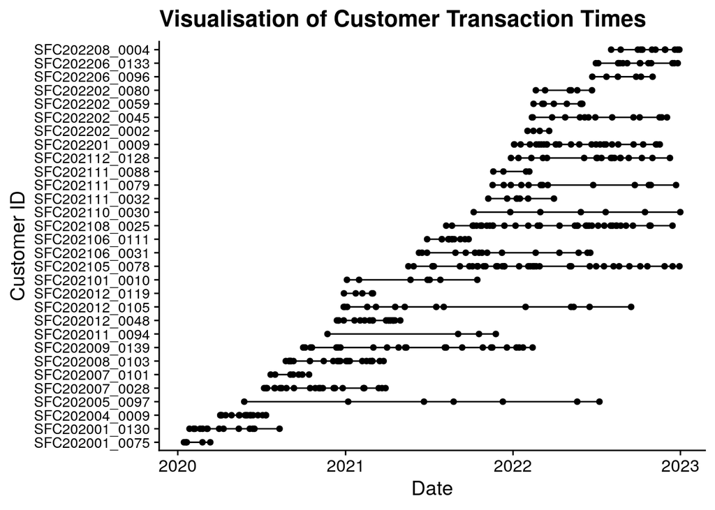

```r
plot_tbl <- customer_transactions_tbl |>
  group_nest(customer_id, .key = "cust_data") |>
  filter(map_int(cust_data, nrow) > 3) |>
  slice_sample(n = 30) |>
  unnest(cust_data)

ggplot(plot_tbl, aes(x = tnx_timestamp, y = customer_id)) +
  geom_line() +
  geom_point() +
  labs(
      x = "Date",
      y = "Customer ID",
      title = "Visualisation of Customer Transaction Times"
    ) +
  theme(axis.text.y = element_text(size = 10))
```

## 3.2 Load Derived Data

```r
obs_fitdata_tbl   <- read_rds("data/shortsynth_obs_fitdata_tbl.rds")
obs_validdata_tbl <- read_rds("data/shortsynth_obs_validdata_tbl.rds")

customer_fit_stats_tbl <- obs_fitdata_tbl |>
  rename(x = tnx_count)
```

## 3.3 Load Subset Data

We also want to construct our data subsets for the purposes of speeding up our valuations.

```r
customer_subset_id <- read_rds("data/shortsynth_customer_subset_ids.rds")
customer_subset_id |> glimpse()
```

```
 Factor w/ 5000 levels "SFC202001_0002",..: 2 3 8 10 14 16 17 21 25 27 ...
```

```r
customer_fit_subset_tbl <- obs_fitdata_tbl |>
  filter(customer_id %in% customer_subset_id)

customer_fit_subset_tbl |> glimpse()
```

```
Rows: 1,000
Columns: 6
$ customer_id    <fct> SFC202001_0004, SFC202001_0001, SFC202001_0008, SFC2020…
$ first_tnx_date <dttm> 2020-01-01 14:02:22, 2020-01-01 15:26:03, 2020-01-02 1…
$ last_tnx_date  <dttm> 2020-01-01 14:02:22, 2020-02-27 10:26:24, 2020-06-14 2…
$ tnx_count      <dbl> 0, 3, 4, 0, 10, 0, 2, 0, 1, 4, 1, 16, 3, 2, 7, 0, 1, 5,…
$ t_x            <dbl> 0.0000000, 8.1131300, 23.4784803, 0.0000000, 28.6442666…
$ T_cal          <dbl> 104.3450, 104.3367, 104.2137, 104.1611, 104.0805, 104.0…
```

```r
customer_valid_subset_tbl <- obs_validdata_tbl |>
  filter(customer_id %in% customer_subset_id)

customer_valid_subset_tbl |> glimpse()
```

```
Rows: 1,000
Columns: 3
$ customer_id       <fct> SFC202001_0004, SFC202001_0001, SFC202001_0008, SFC2…
$ tnx_count         <dbl> 0, 0, 0, 0, 0, 0, 0, 0, 0, 0, 0, 0, 0, 0, 0, 0, 0, 0…
$ tnx_last_interval <dbl> NA, NA, NA, NA, NA, NA, NA, NA, NA, NA, NA, NA, NA, …
```

We now use these datasets to set the start and end dates for our various validation methods.

```r
dates_lst <- read_rds("data/shortsynth_simulation_dates.rds")

use_fit_start_date <- dates_lst$use_fit_start_date
use_fit_end_date   <- dates_lst$use_fit_end_date

use_valid_start_date <- dates_lst$use_valid_start_date
use_valid_end_date   <- dates_lst$use_valid_end_date
```

We now want to split the transaction datasets into two parts.

```r
customer_fitdata_transactions_tbl <- customer_transactions_tbl |>
  filter(
    tnx_timestamp >= use_fit_start_date,
    tnx_timestamp <= use_fit_end_date
    )

customer_fitdata_transactions_tbl |> glimpse()
```

```
Rows: 17,009
Columns: 8
$ customer_id   <fct> SFC202001_0002, SFC202001_0004, SFC202001_0001, SFC20200…
$ tnx_timestamp <dttm> 2020-01-01 08:00:48, 2020-01-01 14:02:22, 2020-01-01 15…
$ tnx_dow       <fct> Wed, Wed, Wed, Wed, Thu, Thu, Thu, Thu, Thu, Thu, Fri, F…
$ tnx_month     <fct> Jan, Jan, Jan, Jan, Jan, Jan, Jan, Jan, Jan, Jan, Jan, J…
$ tnx_week      <chr> "00", "00", "00", "00", "00", "00", "00", "00", "00", "0…
$ invoice_id    <chr> "T20200101-0001", "T20200101-0002", "T20200101-0003", "T…
$ tnx_amount    <dbl> 120.46, 208.45, 386.80, 111.52, 133.66, 133.52, 26.19, 1…
$ orig_id       <chr> "SFC202001_0002", "SFC202001_0004", "SFC202001_0001", "S…
```

```r
customer_fit_transactions_tbl <- customer_fitdata_transactions_tbl |>
  filter(
    customer_id %in% customer_subset_id
    )

customer_fit_transactions_tbl |> glimpse()
```

```
Rows: 5,080
Columns: 8
$ customer_id   <fct> SFC202001_0004, SFC202001_0001, SFC202001_0008, SFC20200…
$ tnx_timestamp <dttm> 2020-01-01 14:02:22, 2020-01-01 15:26:03, 2020-01-02 12…
$ tnx_dow       <fct> Wed, Wed, Thu, Thu, Fri, Fri, Fri, Sat, Sat, Sun, Sun, M…
$ tnx_month     <fct> Jan, Jan, Jan, Jan, Jan, Jan, Jan, Jan, Jan, Jan, Jan, J…
$ tnx_week      <chr> "00", "00", "00", "00", "00", "00", "00", "00", "00", "0…
$ invoice_id    <chr> "T20200101-0002", "T20200101-0003", "T20200102-0004", "T…
$ tnx_amount    <dbl> 208.45, 386.80, 154.71, 80.41, 135.19, 159.46, 229.79, 9…
$ orig_id       <chr> "SFC202001_0004", "SFC202001_0001", "SFC202001_0008", "S…
```

```r
customer_valid_transactions_tbl <- customer_transactions_tbl |>
  filter(
    customer_id %in% customer_subset_id,
    tnx_timestamp >= use_valid_start_date,
    tnx_timestamp <= use_valid_end_date
    )

customer_valid_transactions_tbl |> glimpse()
```

```
Rows: 1,680
Columns: 8
$ customer_id   <fct> SFC202109_0029, SFC202112_0135, SFC202011_0128, SFC20211…
$ tnx_timestamp <dttm> 2022-01-01 01:32:25, 2022-01-01 02:51:43, 2022-01-01 03…
$ tnx_dow       <fct> Sat, Sat, Sat, Sat, Sat, Sat, Sat, Sat, Sun, Sun, Sun, S…
$ tnx_month     <fct> Jan, Jan, Jan, Jan, Jan, Jan, Jan, Jan, Jan, Jan, Jan, J…
$ tnx_week      <chr> "00", "00", "00", "00", "00", "00", "00", "00", "00", "0…
$ invoice_id    <chr> "T20220101-0004", "T20220101-0006", "T20220101-0008", "T…
$ tnx_amount    <dbl> 99.76, 219.92, 315.00, 207.41, 466.45, 168.03, 107.16, 1…
$ orig_id       <chr> "SFC202109_0029", "SFC202112_0135", "SFC202011_0128", "S…
```

## 3.4 Derive the Log-likelihood Function

We now turn our attention to deriving the log-likelihood model for the P/NBD model.

We assume that we know that a given customer has made $x$ transactions after the initial one over an observed period of time $T$, and we label these transactions $t_1$, $t_2$, …, $t_x$.

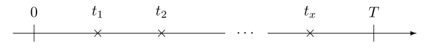

To model the likelihood for this observation, we need to consider two possibilities: one for where the customer is still ‘alive’ at $T$, and one where the customer has ‘died’ by $T$.

In the first instance, the likelihood is the product of the observations of each transaction, multiplied by the likelihood of the customer still being alive at time $T$.

Because we are modelling the transaction counts as a Poisson process, this corresponds to the times between events following an exponential distribution, and so both the transaction times and the lifetime likelihoods use the exponential.

This gives us:

$$\begin{eqnarray*}
L(\lambda \, | \, t_1, t_2, ..., t_x, T, \, \tau > T)
&=& \lambda e^{-\lambda t_1} \lambda e^{-\lambda(t_2 - t_1)} ...
\lambda e^{-\lambda (t_x - t_{x-1})} e^{-\lambda(T - t)} \\
&=& \lambda^x e^{-\lambda T}
\end{eqnarray*}$$

and we can combine this with the likelihood of the lifetime of the customer $\tau$ being greater than the observation window $T$,

$$P(\tau > T \, | \, \mu) = e^{-\mu T}$$

For the second case, the customer becomes inactive at some time $\tau$ in the interval $(t_x, T]$, and so the likelihood is

$$\begin{eqnarray*}
L(\lambda \, | \, t_1, t_2, ..., t_x, T, \, \tau > T)
&=& \lambda e^{-\lambda t_1} \lambda e^{-\lambda(t_2 - t_1)} ...
\lambda e^{-\lambda (t_x - t_{x-1})} e^{-\lambda(\tau - t_x)} \\
&=& \lambda^x e^{-\lambda \tau}
\end{eqnarray*}$$

In both cases we do not need the times of the individual transactions, and all we need are the values $(x, t_x, T)$.

As we cannot observe $\tau$, we want to remove the conditioning on $\tau$ by integrating it out.

$$\begin{eqnarray*}
L(\lambda, \mu \, | \, x, t_x, T)
&=& L(\lambda \, | \, t_1, t_2, ..., t_x, T, \, \tau > T) \, P(\tau > T \, | \, \mu) \; + \\
& & \; \;\; \; \; \;\; \; \int^T_{t_x} L(\lambda \, | \, x, T, \text{ inactive at } (t_x, T] ) \, f(\tau \, | \mu) \, d\tau \\
&=& \lambda^x e^{-\lambda T} e^{\mu T} +
\lambda^x \int^T_{t_x} e^{-\lambda \tau} \mu e^{-\mu \tau} d\tau \\
&=& \lambda^x e^{-(\lambda + \mu)T} + \frac{\lambda^x \mu}{\lambda + \mu} e^{-(\lambda + \mu) t_x} +
\frac{\lambda^x \mu}{\lambda + \mu} e^{-(\lambda + \mu) T} \\
&=& \frac{\lambda^x \mu}{\lambda + \mu} e^{-(\lambda + \mu) t_x} +
\frac{\lambda^{x+1} \mu}{\lambda + \mu} e^{-(\lambda + \mu) T}
\end{eqnarray*}$$

In Stan, we do not calculate the likelihoods but the Log-likelihood, so we need to take the log of this expression. This creates a problem, as we have no easy way to calculate $\log(a + b)$. As this expression occurs a lot, Stan provides a `log_sum_exp()`, which is defined by

$$\ln (a + b) = \text{LogSumExp}(\ln a, \, \ln b)$$

We then use this `log_sum_exp()` function to calculate the Log-Likelihood for the model. Note we use “LogSumExp” here to get around limitations in the renderer.

$$\begin{eqnarray*}
LL(\lambda, \mu \, | \, x, t_x, T)
&=&
\log \left(
\frac{\lambda^x \, \mu}{\lambda + \mu}
\left( e^{-(\lambda + \mu) t_x} + \lambda e^{-(\lambda + \mu) T} \right)
\right) \\
&=& x \log \lambda + \log \mu - \log(\lambda + \mu) \; + \\
& & \;\;\;\;\;\;\; \text{LogSumExp}(-(\lambda + \mu) \, t_x, \; \log \lambda - (\lambda + \mu) \, T)
\end{eqnarray*}$$

This is the log-likelihood model we want to fit in Stan.

# 4 Fit Initial P/NBD Model

We now construct our Stan model and prepare to fit it with our synthetic dataset.

Before we start on that, we set a few parameters for the workbook to organise our Stan code.

```r
stan_modeldir <- "stan_models"
stan_codedir  <-   "stan_code"
```

We start with the Stan model.

```
functions {
  #include util_functions.stan
}

data {
  int<lower=1> n;           // number of customers

  vector<lower=0>[n] t_x;   // time to most recent purchase
  vector<lower=0>[n] T_cal; // total observation time
  vector<lower=0>[n] x;     // number of purchases observed

  real<lower=0> lambda_mn;  // prior mean for lambda
  real<lower=0> lambda_cv;  // prior cv   for lambda

  real<lower=0> mu_mn;      // prior mean for mu
  real<lower=0> mu_cv;      // prior mean for mu
}

transformed data {
  real<lower=0> r     = 1 / (lambda_cv * lambda_cv);
  real<lower=0> alpha = 1 / (lambda_cv * lambda_cv * lambda_mn);

  real<lower=0> s    = 1 / (mu_cv * mu_cv);
  real<lower=0> beta = 1 / (mu_cv * mu_cv * mu_mn);
}


parameters {
  vector<lower=0>[n] lambda; // purchase rate
  vector<lower=0>[n] mu;     // lifetime dropout rate
}


model {
  // setting priors
  lambda ~ gamma(r, alpha);
  mu     ~ gamma(s,  beta);

  target += calculate_pnbd_loglik(n, lambda, mu, x, t_x, T_cal);
}

generated quantities {
  vector[n] p_alive;         // Probability that they are still "alive"

  p_alive = 1 ./ (1 + mu ./ (mu + lambda) .* (exp((lambda + mu) .* (T_cal - t_x)) - 1));
}
```

This file contains a few new features of Stan - named file includes and user-defined functions - `calculate_pnbd_loglik`. We look at this file here:

```
real calculate_pnbd_loglik(int n, vector lambda, vector mu,
                           data vector x, data vector t_x, data vector T_cal) {
  // likelihood
  vector[n] t1;
  vector[n] t2;

  vector[n] lpm;
  vector[n] lht;
  vector[n] rht;

  lpm = lambda + mu;

  lht = log(lambda) - lpm .* T_cal;
  rht = log(mu)     - lpm .* t_x;

  t1  = x .* log(lambda) - log(lpm);

  for (i in 1:n) {
    t2[i] = log_sum_exp(lht[i], rht[i]);
  }

  return(sum(t1) + sum(t2));
}


real calculate_bgnbd_loglik(int n, vector lambda, vector p,
                            data vector x, data vector t_x, data vector T_cal) {
  // likelihood
  vector[n] t1;
  vector[n] t2;

  vector[n] lht;
  vector[n] rht;

  lht = log(p) + (x-1) .* log(1-p) + x .* log(lambda) - lambda .* t_x;
  rht = x .* log(1-p) + x .* log(lambda) - lambda .* T_cal;

  for(i in 1:n) {
    t2[i] = log_sum_exp(lht[i], rht[i]);
  }

  return(sum(t2));
}
```

## 4.1 Compile and Fit Stan Model

We now compile this model using `CmdStanR`.

```r
pnbd_fixed_stanmodel <- cmdstan_model(
  "stan_code/pnbd_fixed.stan",
  include_paths =   stan_codedir,
  pedantic      =           TRUE,
  dir           =  stan_modeldir
  )
```

We then use this compiled model with our data to produce a fit of the data.

```r
stan_modelname <- "pnbd_init"
stanfit_prefix <- str_c("fit_", stan_modelname)
stanfit_seed   <- stanfit_seed + 1

stanfit_object_file <- glue("data/{stanfit_prefix}_stanfit.rds")


stan_data_lst <- customer_fit_stats_tbl |>
  select(customer_id, x, t_x, T_cal) |>
  compose_data(
    lambda_mn = 0.25,
    lambda_cv = 1.00,

    mu_mn     = 0.10,
    mu_cv     = 1.00,
    )

if(!file_exists(stanfit_object_file)) {
  pnbd_init_stanfit <- pnbd_fixed_stanmodel$sample(
    data            =                stan_data_lst,
    chains          =                            4,
    iter_warmup     =                          500,
    iter_sampling   =                          500,
    seed            =                 stanfit_seed,
    save_warmup     =                         TRUE,
    output_dir      =                stan_modeldir,
    output_basename =               stanfit_prefix,
    )

  pnbd_init_stanfit$save_object(stanfit_object_file, compress = "gzip")

} else {
  pnbd_init_stanfit <- read_rds(stanfit_object_file)
}
```

```
Running MCMC with 4 chains, at most 12 in parallel...

Chain 1 Iteration:   1 / 1000 [  0%]  (Warmup)
Chain 2 Iteration:   1 / 1000 [  0%]  (Warmup)
Chain 3 Iteration:   1 / 1000 [  0%]  (Warmup)
Chain 4 Iteration:   1 / 1000 [  0%]  (Warmup)
Chain 2 Iteration: 100 / 1000 [ 10%]  (Warmup)
Chain 3 Iteration: 100 / 1000 [ 10%]  (Warmup)
Chain 4 Iteration: 100 / 1000 [ 10%]  (Warmup)
Chain 1 Iteration: 100 / 1000 [ 10%]  (Warmup)
Chain 3 Iteration: 200 / 1000 [ 20%]  (Warmup)
Chain 2 Iteration: 200 / 1000 [ 20%]  (Warmup)
Chain 4 Iteration: 200 / 1000 [ 20%]  (Warmup)
Chain 1 Iteration: 200 / 1000 [ 20%]  (Warmup)
Chain 3 Iteration: 300 / 1000 [ 30%]  (Warmup)
Chain 2 Iteration: 300 / 1000 [ 30%]  (Warmup)
Chain 4 Iteration: 300 / 1000 [ 30%]  (Warmup)
Chain 1 Iteration: 300 / 1000 [ 30%]  (Warmup)
Chain 3 Iteration: 400 / 1000 [ 40%]  (Warmup)
Chain 2 Iteration: 400 / 1000 [ 40%]  (Warmup)
Chain 4 Iteration: 400 / 1000 [ 40%]  (Warmup)
Chain 1 Iteration: 400 / 1000 [ 40%]  (Warmup)
Chain 3 Iteration: 500 / 1000 [ 50%]  (Warmup)
Chain 3 Iteration: 501 / 1000 [ 50%]  (Sampling)
Chain 2 Iteration: 500 / 1000 [ 50%]  (Warmup)
Chain 2 Iteration: 501 / 1000 [ 50%]  (Sampling)
Chain 4 Iteration: 500 / 1000 [ 50%]  (Warmup)
Chain 4 Iteration: 501 / 1000 [ 50%]  (Sampling)
Chain 1 Iteration: 500 / 1000 [ 50%]  (Warmup)
Chain 1 Iteration: 501 / 1000 [ 50%]  (Sampling)
Chain 3 Iteration: 600 / 1000 [ 60%]  (Sampling)
Chain 2 Iteration: 600 / 1000 [ 60%]  (Sampling)
Chain 4 Iteration: 600 / 1000 [ 60%]  (Sampling)
Chain 1 Iteration: 600 / 1000 [ 60%]  (Sampling)
Chain 3 Iteration: 700 / 1000 [ 70%]  (Sampling)
Chain 2 Iteration: 700 / 1000 [ 70%]  (Sampling)
Chain 4 Iteration: 700 / 1000 [ 70%]  (Sampling)
Chain 1 Iteration: 700 / 1000 [ 70%]  (Sampling)
Chain 3 Iteration: 800 / 1000 [ 80%]  (Sampling)
Chain 2 Iteration: 800 / 1000 [ 80%]  (Sampling)
Chain 4 Iteration: 800 / 1000 [ 80%]  (Sampling)
Chain 1 Iteration: 800 / 1000 [ 80%]  (Sampling)
Chain 3 Iteration: 900 / 1000 [ 90%]  (Sampling)
Chain 2 Iteration: 900 / 1000 [ 90%]  (Sampling)
Chain 4 Iteration: 900 / 1000 [ 90%]  (Sampling)
Chain 1 Iteration: 900 / 1000 [ 90%]  (Sampling)
Chain 3 Iteration: 1000 / 1000 [100%]  (Sampling)
Chain 3 finished in 121.0 seconds.
Chain 2 Iteration: 1000 / 1000 [100%]  (Sampling)
Chain 2 finished in 121.5 seconds.
Chain 4 Iteration: 1000 / 1000 [100%]  (Sampling)
Chain 4 finished in 124.5 seconds.
Chain 1 Iteration: 1000 / 1000 [100%]  (Sampling)
Chain 1 finished in 125.2 seconds.

All 4 chains finished successfully.
Mean chain execution time: 123.1 seconds.
Total execution time: 125.5 seconds.
```

```r
pnbd_init_stanfit$print()
```

```
  variable      mean    median    sd   mad        q5       q95 rhat ess_bulk
 lp__      -51308.58 -51308.20 64.78 65.09 -51413.90 -51204.40 1.00      649
 lambda[1]      0.24      0.22  0.11  0.10      0.09      0.44 1.00     3110
 lambda[2]      0.14      0.08  0.18  0.10      0.00      0.51 1.00     1695
 lambda[3]      0.27      0.24  0.15  0.14      0.09      0.56 1.00     1657
 lambda[4]      0.14      0.08  0.17  0.09      0.00      0.50 1.00     1712
 lambda[5]      0.14      0.08  0.17  0.10      0.01      0.47 1.00     1880
 lambda[6]      0.30      0.28  0.14  0.12      0.12      0.55 1.00     2191
 lambda[7]      0.14      0.11  0.11  0.09      0.02      0.37 1.00     1489
 lambda[8]      0.15      0.14  0.07  0.07      0.06      0.28 1.00     2128
 lambda[9]      0.54      0.49  0.27  0.25      0.20      1.03 1.00     2319
 ess_tail
     1123
     1563
      996
     1324
      932
      979
     1006
     1043
     1384
     1500

 # showing 10 of 9961 rows (change via 'max_rows' argument or 'cmdstanr_max_rows' option)
```

We have some basic HMC-based validity statistics we can check.

```r
pnbd_init_stanfit$cmdstan_diagnose()
```

```
Processing csv files: /home/rstudio/btydwork/stan_models/fit_pnbd_init-1.csvWarning: non-fatal error reading adaptation data
, /home/rstudio/btydwork/stan_models/fit_pnbd_init-2.csvWarning: non-fatal error reading adaptation data
, /home/rstudio/btydwork/stan_models/fit_pnbd_init-3.csvWarning: non-fatal error reading adaptation data
, /home/rstudio/btydwork/stan_models/fit_pnbd_init-4.csvWarning: non-fatal error reading adaptation data


Checking sampler transitions treedepth.
Treedepth satisfactory for all transitions.

Checking sampler transitions for divergences.
No divergent transitions found.

Checking E-BFMI - sampler transitions HMC potential energy.
E-BFMI satisfactory.

Effective sample size satisfactory.

Split R-hat values satisfactory all parameters.

Processing complete, no problems detected.
```

## 4.2 Visual Diagnostics of the Sample Validity

Now that we have a sample from the posterior distribution we need to create a few different visualisations of the diagnostics.

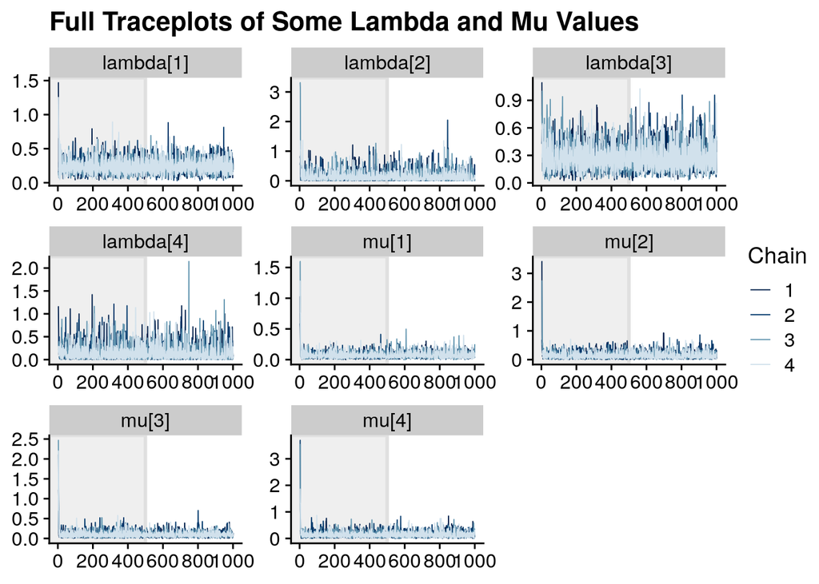

```r
parameter_subset <- c(
  "lambda[1]", "lambda[2]", "lambda[3]", "lambda[4]",
  "mu[1]",     "mu[2]",     "mu[3]",     "mu[4]"
  )

pnbd_init_stanfit$draws(inc_warmup = TRUE) |>
  mcmc_trace(
    pars     = parameter_subset,
    n_warmup = 500
    ) +
  ggtitle("Full Traceplots of Some Lambda and Mu Values")
```

As the warmup is skewing the y-axis somewhat, we repeat this process without the warmup.

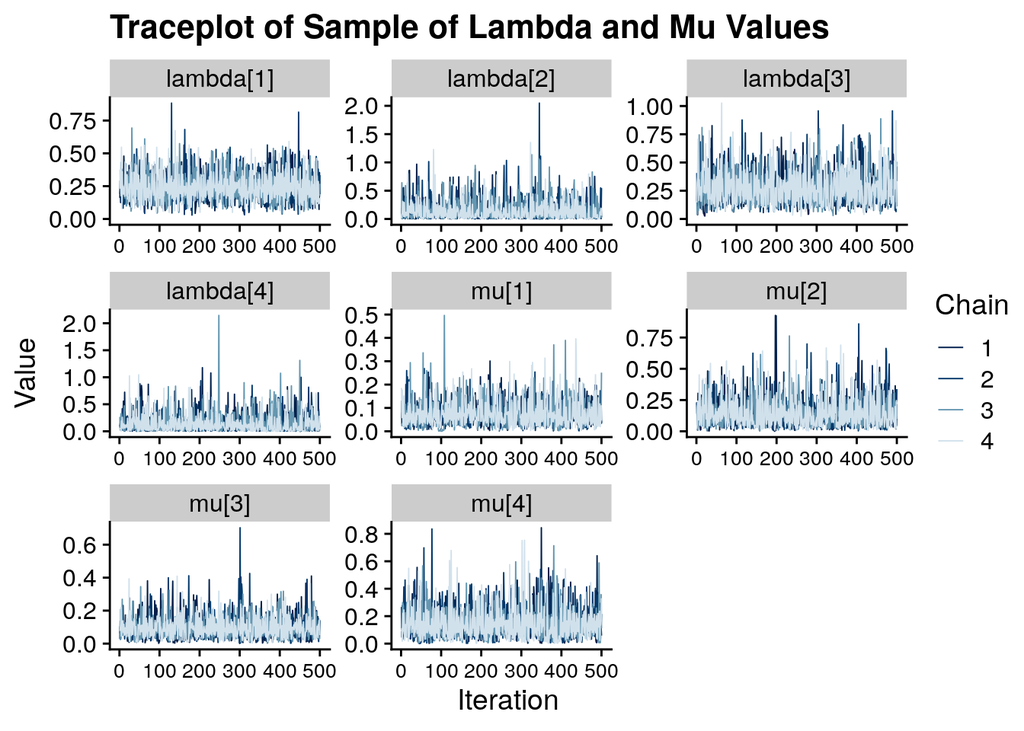

```r
pnbd_init_stanfit$draws(inc_warmup = FALSE) |>
  mcmc_trace(pars = parameter_subset) +
  expand_limits(y = 0) +
  labs(
    x = "Iteration",
    y = "Value",
    title = "Traceplot of Sample of Lambda and Mu Values"
    ) +
  theme(axis.text.x = element_text(size = 10))
```

A common MCMC diagnostic is $\hat{R}$ - which is a measure of the ‘similarity’ of the chains.

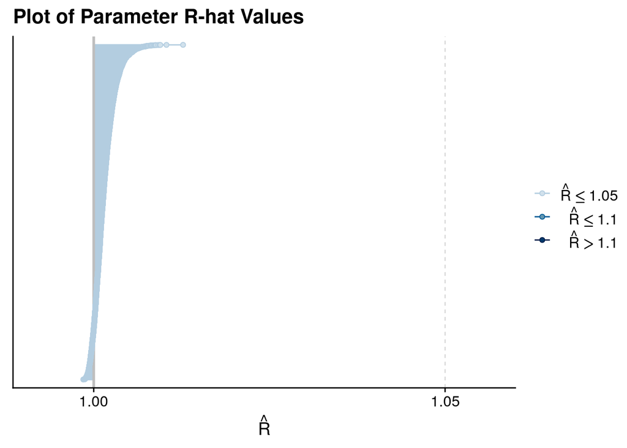

```r
pnbd_init_stanfit |>
  rhat(pars = c("lambda", "mu")) |>
  mcmc_rhat() +
    ggtitle("Plot of Parameter R-hat Values")
```

Related to this quantity is the concept of *effective sample size*, $N_{eff}$, an estimate of the size of the sample from a statistical information point of view.

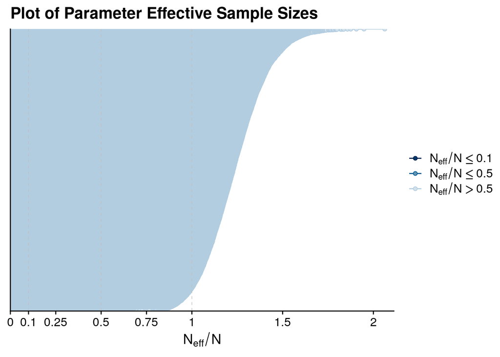

```r
pnbd_init_stanfit |>
  neff_ratio(pars = c("lambda", "mu")) |>
  mcmc_neff() +
    ggtitle("Plot of Parameter Effective Sample Sizes")
```

Finally, we also want to look at autocorrelation in the chains for each parameter.

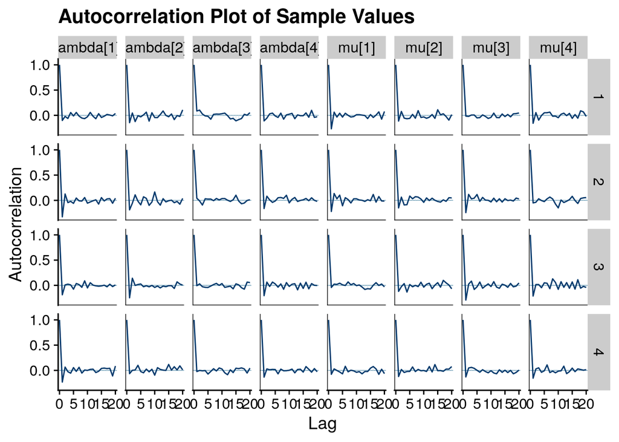

```r
pnbd_init_stanfit$draws() |>
  mcmc_acf(pars = parameter_subset) +
    ggtitle("Autocorrelation Plot of Sample Values")
```

As before, this first fit has a comprehensive run of fit diagnostics, but for the sake of brevity in later models we will show only the traceplots once we are satisfied with the validity of the sample.

## 4.3 Check Model Fit

As we are still working with synthetic data, we know the true values for each customer and so we can check how good our model is at recovering the true values on a customer-by-customer basis.

As in previous workbooks, we build our validation datasets and then check the distribution of $q$-values for both $\lambda$ and $\mu$ across the customer base.

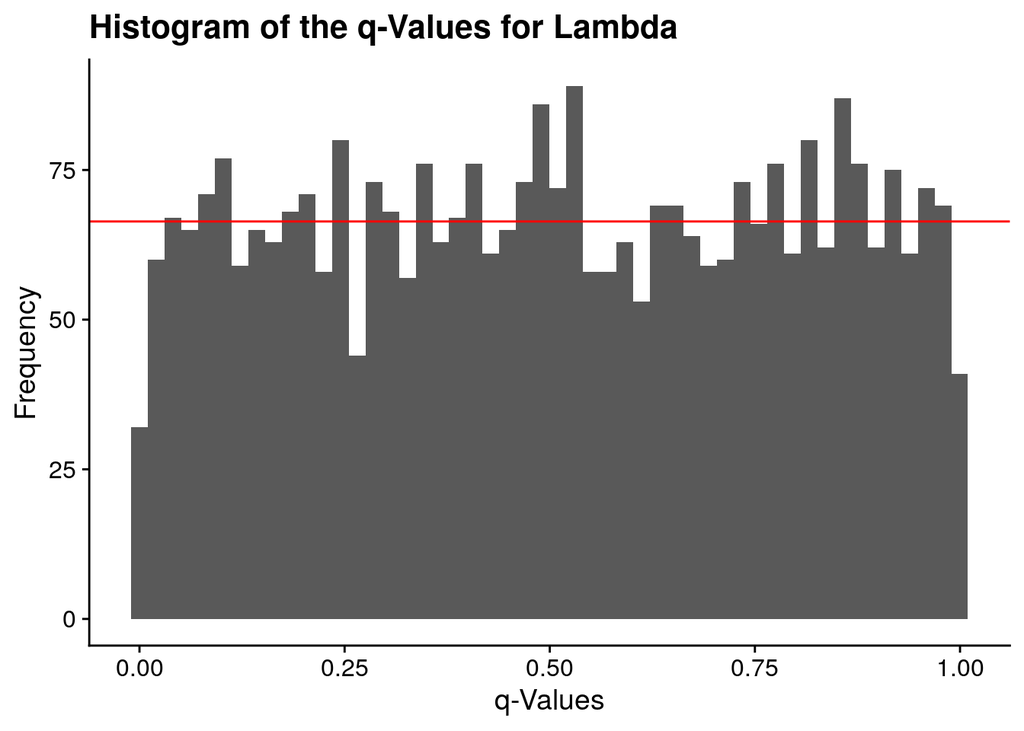

```r
pnbd_init_valid_lst <- create_pnbd_posterior_validation_data(
  stanfit       = pnbd_init_stanfit,
  data_tbl      = customer_fit_stats_tbl,
  simparams_tbl = customer_simparams_tbl
  )

pnbd_init_valid_lst$lambda_qval_plot |> plot()
```

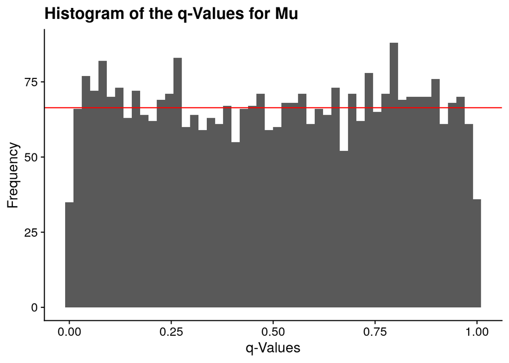

```r
pnbd_init_valid_lst$mu_qval_plot |> plot()
```

These plots looks like the model is recovering the parameters well, but cannot rely on this approach once we use real data so we will stop using this now.

## 4.4 Assess Model Fit Using Simulation

Rather than relying on knowing the ‘true’ answer, we instead will use our posterior sample to generate data and compare this simulated data against the data we fit. This procedure is similar to what we did before but now we focus on in sample data rather than using validation data.

```r
pnbd_stanfit <- pnbd_init_stanfit |>
  recover_types(customer_fit_stats_tbl)

pnbd_init_simstats_tbl <- construct_pnbd_posterior_statistics(
  stanfit         = pnbd_stanfit,
  fitdata_tbl     = customer_fit_subset_tbl
  )

pnbd_init_simstats_tbl |> glimpse()
```

```
Rows: 2,000,000
Columns: 6
$ customer_id    <fct> SFC202001_0004, SFC202001_0004, SFC202001_0004, SFC2020…
$ first_tnx_date <dttm> 2020-01-01 14:02:22, 2020-01-01 14:02:22, 2020-01-01 1…
$ draw_id        <int> 1, 2, 3, 4, 5, 6, 7, 8, 9, 10, 11, 12, 13, 14, 15, 16, …
$ post_lambda    <dbl> 0.06878010, 0.05686180, 0.01114120, 0.54283000, 0.01458…
$ post_mu        <dbl> 0.2331520, 0.0726952, 0.0338550, 0.3040080, 0.0760142, …
$ p_alive        <dbl> 2.69026e-14, 2.39822e-06, 1.21110e-02, 1.17277e-38, 9.3…
```

We now want to write out the simulation stats to disk.

```r
#! echo: TRUE

pnbd_init_simstats_tbl |>
  write_rds("data/pnbd_init_assess_model_simstats_tbl.rds", compress = "gz")
```

We then use these posterior statistics as inputs to our simulations to help us assess the in-sample quality of fit.

```r
fit_label <- "pnbd_init"

precompute_dir <- glue("precompute/{fit_label}")

ensure_exists_precompute_directory(precompute_dir)
```

```
[1] TRUE
```

```r
pnbd_init_fitsims_index_tbl <- pnbd_init_simstats_tbl |>
  mutate(
    start_dttm = first_tnx_date   |> as.POSIXct(),
    end_dttm   = use_fit_end_date |> as.POSIXct(),
    lambda     = post_lambda,
    mu         = post_mu,
    p_alive    = 1,      ### In-sample validation, so customer begins active
    tnx_mu     = 100,    ### We are not simulating tnx size, so put in defaults
    tnx_cv     = 1       ###
    ) |>
  group_nest(customer_id, .key = "cust_params", keep = TRUE) |>
  mutate(
    sim_file = glue(
      "{precompute_dir}/sims_fit_{fit_label}_{customer_id}.rds"
      )
    )


pnbd_init_fitsims_index_tbl |> glimpse()
```

```
Rows: 1,000
Columns: 3
$ customer_id <fct> SFC202001_0004, SFC202001_0001, SFC202001_0008, SFC202001_…
$ cust_params <list<tibble[,12]>> [<tbl_df[2000 x 12]>], [<tbl_df[2000 x 12]>]…
$ sim_file    <glue> "precompute/pnbd_init/sims_fit_pnbd_init_SFC202001_0004.r…
```

We now use this setup to generate our simulations.

```r
precomputed_tbl <- dir_ls(glue("{precompute_dir}")) |>
  as.character() |>
  enframe(name = NULL, value = "sim_file")


runsims_tbl <- pnbd_init_fitsims_index_tbl |>
  anti_join(precomputed_tbl, by = "sim_file")


if(nrow(runsims_tbl) > 0) {
  pnbd_init_fitsims_index_tbl <- runsims_tbl |>
    mutate(
      chunk_data = future_map2_int(
        cust_params, sim_file,
        run_simulations_chunk,

        sim_func = generate_pnbd_validation_transactions,

        .options = furrr_options(
          globals  = c(
            "calculate_event_times", "rgamma_mucv", "gamma_mucv2shaperate",
            "generate_pnbd_validation_transactions"
            ),
          packages   = c("tidyverse", "fs"),
          scheduling = Inf,
          seed       = 421
          ),

        .progress = TRUE
        )
      )
}


pnbd_init_fitsims_index_tbl |> glimpse()
```

```
Rows: 1,000
Columns: 3
$ customer_id <fct> SFC202001_0004, SFC202001_0001, SFC202001_0008, SFC202001_…
$ cust_params <list<tibble[,12]>> [<tbl_df[2000 x 12]>], [<tbl_df[2000 x 12]>]…
$ sim_file    <glue> "precompute/pnbd_init/sims_fit_pnbd_init_SFC202001_0004.r…
```

We now want to load up the summary statistics for each of our customers for later analysis.

```r
retrieve_sim_stats <- ~ .x |>
  read_rds() |>
  select(draw_id, sim_data, sim_tnx_count, sim_tnx_last)
```

```r
pnbd_init_fit_simstats_tbl <- pnbd_init_fitsims_index_tbl |>
  mutate(
    sim_data = map(
      sim_file, retrieve_sim_stats,

      .progress = "pnbd_init_fit"
      )
    ) |>
  select(customer_id, sim_data) |>
  unnest(sim_data)

pnbd_init_fit_simstats_tbl |> glimpse()
```

```
Rows: 2,000,000
Columns: 5
$ customer_id   <fct> SFC202001_0004, SFC202001_0004, SFC202001_0004, SFC20200…
$ draw_id       <int> 1, 2, 3, 4, 5, 6, 7, 8, 9, 10, 11, 12, 13, 14, 15, 16, 1…
$ sim_data      <list> [<tbl_df[0 x 2]>], [<tbl_df[2 x 2]>], [<tbl_df[1 x 2]>]…
$ sim_tnx_count <int> 0, 2, 1, 5, 0, 10, 0, 7, 1, 0, 2, 0, 1, 1, 3, 0, 0, 0, 1…
$ sim_tnx_last  <dttm> NA, 2020-06-13 06:07:30, 2020-03-03 14:48:42, 2020-03-0…
```

We now use this data to check how well our model fits the data.

### 4.4.1 Compare Counts of Multitransaction Customers

We start by checking the high level summary statistics, such as customers with more than one transaction both in the observed data and the simulation data, total transaction count observed

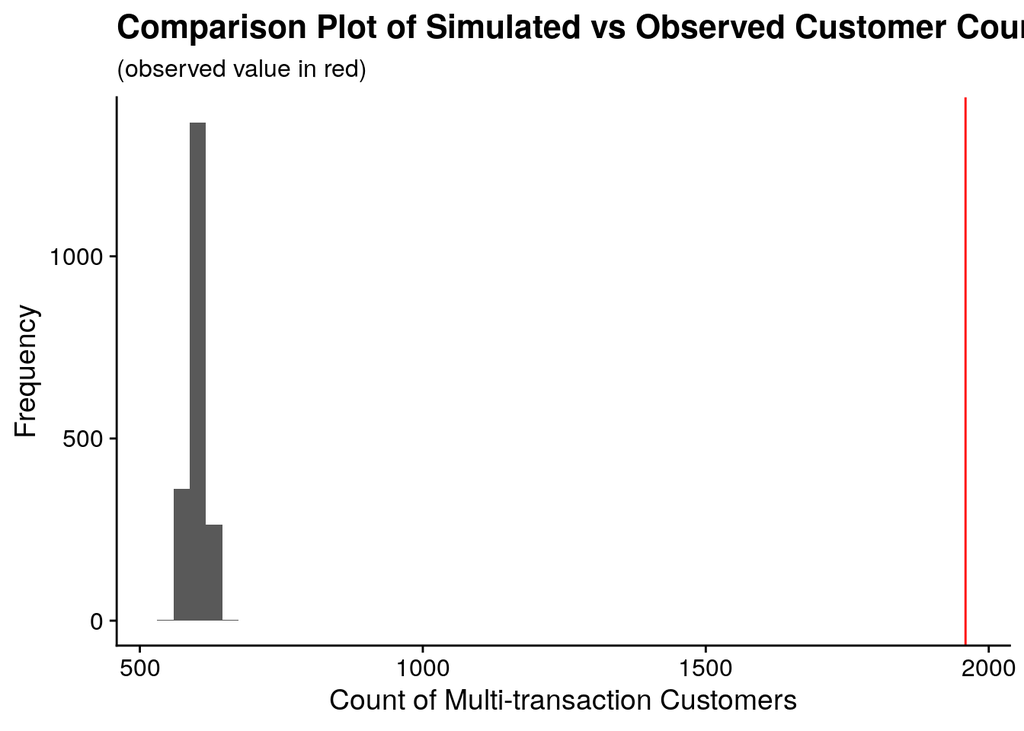

```r
obs_customer_count <- customer_fit_stats_tbl |>
  filter(x > 0) |>
  nrow()

sim_data_tbl <- pnbd_init_fit_simstats_tbl |>
  filter(sim_tnx_count > 0) |>
  count(draw_id, name = "sim_customer_count")

ggplot(sim_data_tbl) +
  geom_histogram(aes(x = sim_customer_count), bins = 50) +
  geom_vline(aes(xintercept = obs_customer_count), colour = "red") +
  labs(
    x = "Count of Multi-transaction Customers",
    y = "Frequency",
    title = "Comparison Plot of Simulated vs Observed Customer Counts",
    subtitle = "(observed value in red)"
    )
```

### 4.4.2 Total Transaction Count

We now check the count of all transactions.

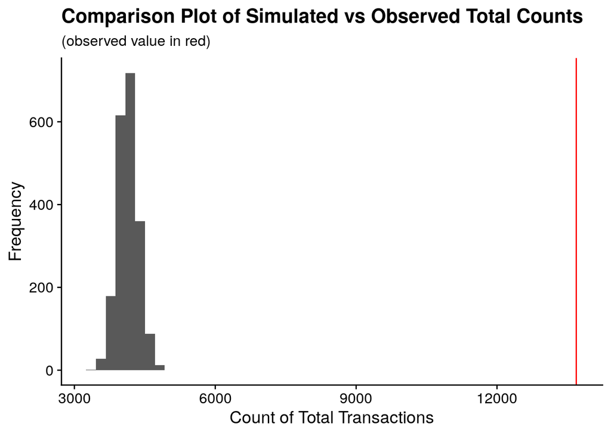

```r
obs_total_count <- customer_fit_stats_tbl |>
  pull(x) |>
  sum()

sim_data_tbl <- pnbd_init_fit_simstats_tbl |>
  count(draw_id, wt = sim_tnx_count, name = "sim_total_count")


ggplot(sim_data_tbl) +
  geom_histogram(aes(x = sim_total_count), bins = 50) +
  geom_vline(aes(xintercept = obs_total_count), colour = "red") +
  labs(
    x = "Count of Total Transactions",
    y = "Frequency",
    title = "Comparison Plot of Simulated vs Observed Total Counts",
    subtitle = "(observed value in red)"
    )
```

### 4.4.3 Transaction Count Quantiles

We now look at the quantiles for the transaction counts across each customer.

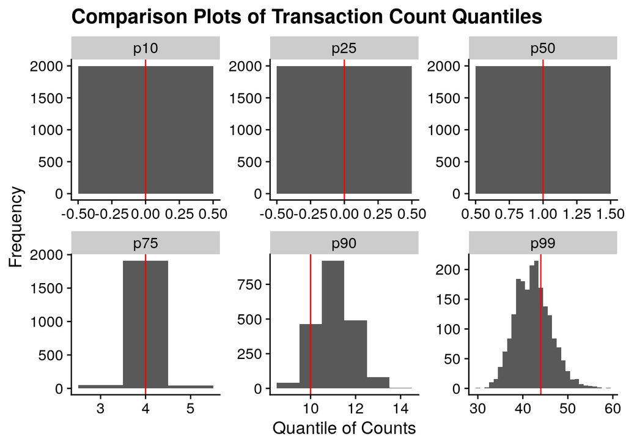

```r
obs_quantiles_tbl <- customer_fit_stats_tbl |>
  reframe(
    prob_label = c("p10", "p25", "p50", "p75", "p90", "p99"),
    prob_value = quantile(x, probs = c(0.10, 0.25, 0.50, 0.75, 0.90, 0.99))
    )

sim_data_tbl <- pnbd_init_fit_simstats_tbl |>
  group_by(draw_id) |>
  summarise(
    p10 = quantile(sim_tnx_count, 0.10),
    p25 = quantile(sim_tnx_count, 0.25),
    p50 = quantile(sim_tnx_count, 0.50),
    p75 = quantile(sim_tnx_count, 0.75),
    p90 = quantile(sim_tnx_count, 0.90),
    p99 = quantile(sim_tnx_count, 0.99)
    ) |>
  pivot_longer(
    cols = !draw_id,
    names_to  = "prob_label",
    values_to = "sim_prob_values"
    ) |>
  inner_join(obs_quantiles_tbl, by = "prob_label")

ggplot(sim_data_tbl) +
  geom_histogram(aes(x = sim_prob_values), binwidth = 1) +
  geom_vline(aes(xintercept = prob_value), colour = "red") +
  facet_wrap(vars(prob_label), nrow = 2, scales = "free") +
  labs(
    x = "Quantile of Counts",
    y = "Frequency",
    title = "Comparison Plots of Transaction Count Quantiles"
    )
```

### 4.4.4 Check Overall Day-of-Week Transaction Patterns

We now want to check our assumption of each customer having a single rate of transaction frequency. This will manifest as a distribution of days of the week (and possibly months of the year), when contrasted with our simulations.

We will do this both by individual year and overall dataset.

```r
dow_props_fit_lst <- customer_fit_transactions_tbl |>
  calculate_dow_proportions()

tnx_fit_overall_dow_tbl   <- dow_props_fit_lst$overall
tnx_fit_yearmonth_dow_tbl <- dow_props_fit_lst$yearmonth


tnx_fit_overall_dow_tbl   |> glimpse()
```

```
Rows: 7
Columns: 3
$ dow_label <chr> "0-Sun", "1-Mon", "2-Tue", "3-Wed", "4-Thu", "5-Fri", "6-Sat"
$ obs_count <int> 730, 738, 744, 697, 721, 702, 748
$ obs_prop  <dbl> 0.1437008, 0.1452756, 0.1464567, 0.1372047, 0.1419291, 0.138…
```

```r
tnx_fit_yearmonth_dow_tbl |> glimpse()
```

```
Rows: 168
Columns: 4
$ yearmonth_date <date> 2020-01-01, 2020-01-01, 2020-01-01, 2020-01-01, 2020-0…
$ dow_label      <chr> "0-Sun", "1-Mon", "2-Tue", "3-Wed", "4-Thu", "5-Fri", "…
$ obs_count      <int> 15, 11, 7, 7, 8, 9, 9, 12, 9, 14, 11, 20, 13, 15, 13, 2…
$ obs_prop       <dbl> 0.22727273, 0.16666667, 0.10606061, 0.10606061, 0.12121…
```

We now need to do the same thing for our simulations and then construct a comparison plot.

```r
sim_fit_tnxdata_tbl <- pnbd_init_fit_simstats_tbl |>
  select(customer_id, draw_id, sim_data) |>
  unnest(sim_data)

propdata_fit_tbl <- sim_fit_tnxdata_tbl |>
  group_nest(draw_id) |>
  mutate(
    prop_data = map(
      data, calculate_dow_proportions,

      .progress = "calculate_dow_propotions"
      ),
    overall_data   = map(prop_data, "overall"),
    yearmonth_data = map(prop_data, "yearmonth")
    )

propdata_fit_tbl |> glimpse()
```

```
Rows: 2,000
Columns: 5
$ draw_id        <int> 1, 2, 3, 4, 5, 6, 7, 8, 9, 10, 11, 12, 13, 14, 15, 16, …
$ data           <list<tibble[,3]>> [<tbl_df[3809 x 3]>], [<tbl_df[4037 x 3]>]…
$ prop_data      <list> [[<tbl_df[7 x 3]>], [<tbl_df[167 x 4]>]], [[<tbl_df[7 …
$ overall_data   <list> [<tbl_df[7 x 3]>], [<tbl_df[7 x 3]>], [<tbl_df[7 x 3]>…
$ yearmonth_data <list> [<tbl_df[167 x 4]>], [<tbl_df[168 x 4]>], [<tbl_df[167…
```

We now want to compare the simulation data against the observed proportions.

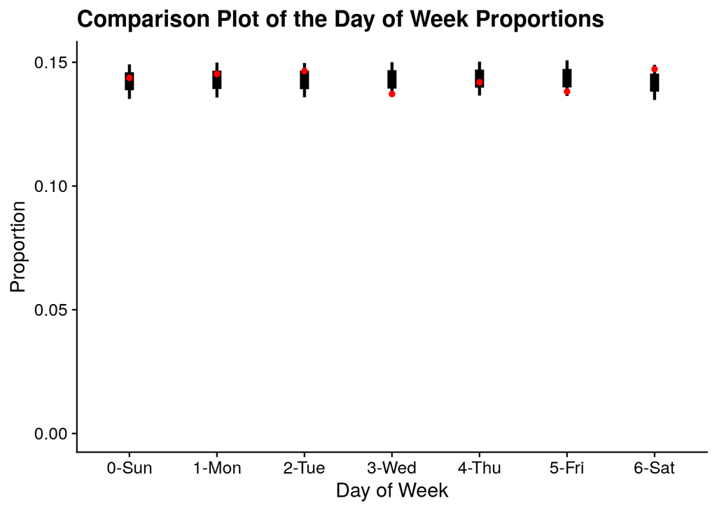

```r
simplot_fit_tbl <- propdata_fit_tbl |>
  select(draw_id, overall_data) |>
  unnest(overall_data) |>
  group_by(dow_label) |>
  summarise(
    .groups = "drop",

    p10 = quantile(obs_prop, 0.10),
    p25 = quantile(obs_prop, 0.25),
    p50 = quantile(obs_prop, 0.50),
    p75 = quantile(obs_prop, 0.75),
    p90 = quantile(obs_prop, 0.90)
    )

ggplot(simplot_fit_tbl) +
  geom_errorbar(
    aes(x = dow_label, ymin = p10, ymax = p90),
    width = 0, linewidth = 1
    ) +
  geom_errorbar(
    aes(x = dow_label, ymin = p25, ymax = p75),
    width = 0, linewidth = 3
    ) +
  geom_point(
    aes(x = dow_label, y = obs_prop),
    data = tnx_fit_overall_dow_tbl, colour = "red"
    ) +
  expand_limits(y = 0) +
  labs(
    x = "Day of Week",
    y = "Proportion",
    title = "Comparison Plot of the Day of Week Proportions"
    )
```

### 4.4.5 Check Monthly Day-of-Week Transaction Patterns

We now want to compare the plots for each of the days of week.

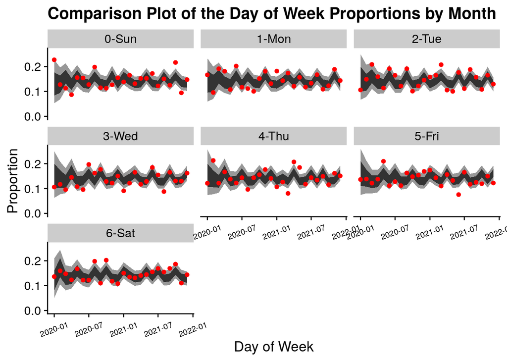

```r
simplot_fit_tbl <- propdata_fit_tbl |>
  select(draw_id, yearmonth_data) |>
  unnest(yearmonth_data) |>
  group_by(dow_label, yearmonth_date) |>
  summarise(
    .groups = "drop",

    p10 = quantile(obs_prop, 0.10),
    p25 = quantile(obs_prop, 0.25),
    p50 = quantile(obs_prop, 0.50),
    p75 = quantile(obs_prop, 0.75),
    p90 = quantile(obs_prop, 0.90)
    )

ggplot(simplot_fit_tbl) +
  geom_ribbon(
    aes(x = yearmonth_date, ymin = p10, ymax = p90),
    alpha = 0.5
    ) +
  geom_ribbon(
    aes(x = yearmonth_date, ymin = p25, ymax = p75),
    alpha = 1.0
    ) +
  geom_point(
    aes(x = yearmonth_date, y = obs_prop),
    data = tnx_fit_yearmonth_dow_tbl, colour = "red"
    ) +
  facet_wrap(vars(dow_label)) +
  expand_limits(y = 0) +
  labs(
    x = "Day of Week",
    y = "Proportion",
    title = "Comparison Plot of the Day of Week Proportions by Month"
    ) +
  theme(axis.text.x = element_text(angle = 20, size = 8, vjust = 0.5))
```

### 4.4.6 Write to Disk

We write this data to disk

```r
pnbd_init_fit_simstats_tbl |>
  write_rds("data/pnbd_init_assess_fit_simstats_tbl.rds", compress = "gz")
```

## 4.5 Assess Out-of-Sample Data

We now repeat this exercise, but for the validation period of 2022.

```r
precompute_dir <- glue("precompute/{fit_label}")

ensure_exists_precompute_directory(precompute_dir)
```

```
[1] TRUE
```

```r
use_start <- use_valid_start_date |> as.POSIXct()
use_final <- use_valid_end_date   |> as.POSIXct()


pnbd_init_validsims_index_tbl <- pnbd_init_simstats_tbl |>
  mutate(
    start_dttm = use_start,
    end_dttm   = use_final,
    lambda     = post_lambda,
    mu         = post_mu,
    tnx_mu     = 1,      ### We are not simulating tnx size
    tnx_cv     = 1       ###
    ) |>
  group_nest(customer_id, .key = "cust_params", keep = TRUE) |>
  mutate(
    sim_file = glue(
      "{precompute_dir}/sims_valid_{fit_label}_{customer_id}.rds"
      )
    )

pnbd_init_validsims_index_tbl |> glimpse()
```

```
Rows: 1,000
Columns: 3
$ customer_id <fct> SFC202001_0004, SFC202001_0001, SFC202001_0008, SFC202001_…
$ cust_params <list<tibble[,12]>> [<tbl_df[2000 x 12]>], [<tbl_df[2000 x 12]>]…
$ sim_file    <glue> "precompute/pnbd_init/sims_valid_pnbd_init_SFC202001_0004…
```

We now can run these simulations to check how well our model captures transactions out of the fitted data.

```r
precomputed_tbl <- dir_ls(glue("{precompute_dir}")) |>
  as.character() |>
  enframe(name = NULL, value = "sim_file")


runsims_tbl <- pnbd_init_validsims_index_tbl |>
  anti_join(precomputed_tbl, by = "sim_file")


if(nrow(runsims_tbl) > 0) {
  pnbd_init_validsims_index_tbl <- runsims_tbl |>
    mutate(
      chunk_data = future_map2_int(
        cust_params, sim_file,
        run_simulations_chunk,

        sim_func = generate_pnbd_validation_transactions,

        .options = furrr_options(
          globals  = c(
            "calculate_event_times", "rgamma_mucv", "gamma_mucv2shaperate",
            "generate_pnbd_validation_transactions"
            ),
          packages   = c("tidyverse", "fs"),
          scheduling = Inf,
          seed       = 421
          ),

        .progress = TRUE
        )
      )
}

pnbd_init_validsims_index_tbl |> glimpse()
```

```
Rows: 1,000
Columns: 3
$ customer_id <fct> SFC202001_0004, SFC202001_0001, SFC202001_0008, SFC202001_…
$ cust_params <list<tibble[,12]>> [<tbl_df[2000 x 12]>], [<tbl_df[2000 x 12]>]…
$ sim_file    <glue> "precompute/pnbd_init/sims_valid_pnbd_init_SFC202001_0004…
```

Now that we have generated our simulations we want to load the data from the files and construct a dataset for use as part of the validation.

```r
pnbd_init_valid_simstats_tbl <- pnbd_init_validsims_index_tbl |>
  mutate(
    sim_data = map(
      sim_file, retrieve_sim_stats,

      .progress = "pnbd_init_valid"
      )
    ) |>
  select(customer_id, sim_data) |>
  unnest(sim_data)

pnbd_init_valid_simstats_tbl |> glimpse()
```

```
Rows: 2,000,000
Columns: 5
$ customer_id   <fct> SFC202001_0004, SFC202001_0004, SFC202001_0004, SFC20200…
$ draw_id       <int> 1, 2, 3, 4, 5, 6, 7, 8, 9, 10, 11, 12, 13, 14, 15, 16, 1…
$ sim_data      <list> [<tbl_df[0 x 2]>], [<tbl_df[0 x 2]>], [<tbl_df[0 x 2]>]…
$ sim_tnx_count <int> 0, 0, 0, 0, 0, 0, 0, 0, 0, 1, 0, 0, 0, 0, 0, 0, 0, 0, 0,…
$ sim_tnx_last  <dttm> NA, NA, NA, NA, NA, NA, NA, NA, NA, 2022-08-26 21:28:48…
```

### 4.5.1 Compare Counts of Multitransaction Customers

We start by checking the high level summary statistics, such as customers with more than one transaction both in the observed data and the simulation data, total transaction count observed

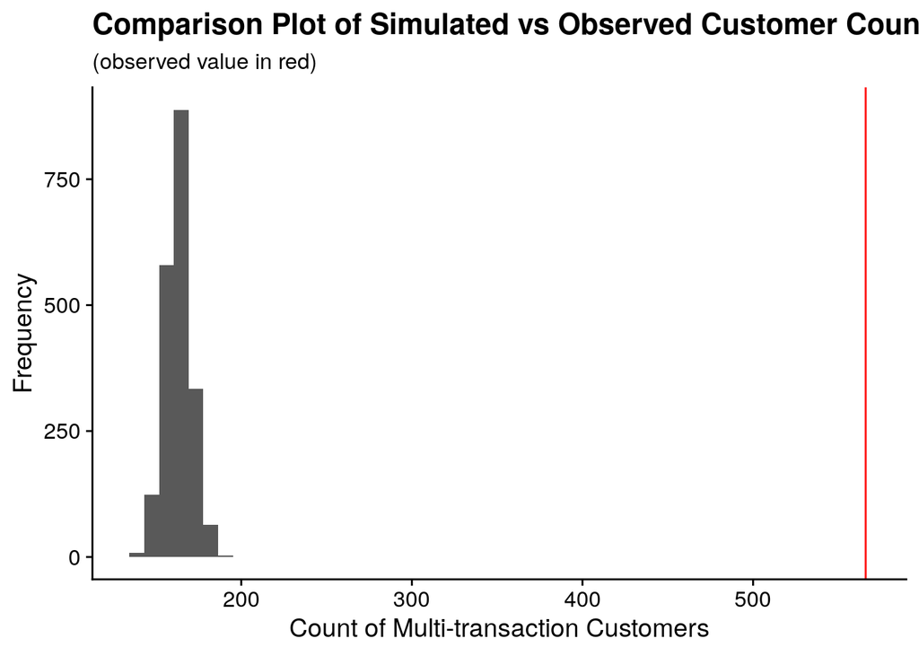

```r
obs_customer_count <- customer_valid_stats_tbl |>
  filter(tnx_count > 0) |>
  nrow()

sim_data_tbl <- pnbd_init_valid_simstats_tbl |>
  filter(sim_tnx_count > 0) |>
  count(draw_id, name = "sim_customer_count")

ggplot(sim_data_tbl) +
  geom_histogram(aes(x = sim_customer_count), bins = 50) +
  geom_vline(aes(xintercept = obs_customer_count), colour = "red") +
  labs(
    x = "Count of Multi-transaction Customers",
    y = "Frequency",
    title = "Comparison Plot of Simulated vs Observed Customer Counts",
    subtitle = "(observed value in red)"
    )
```

### 4.5.2 Total Transaction Count

We now check the count of all transactions.

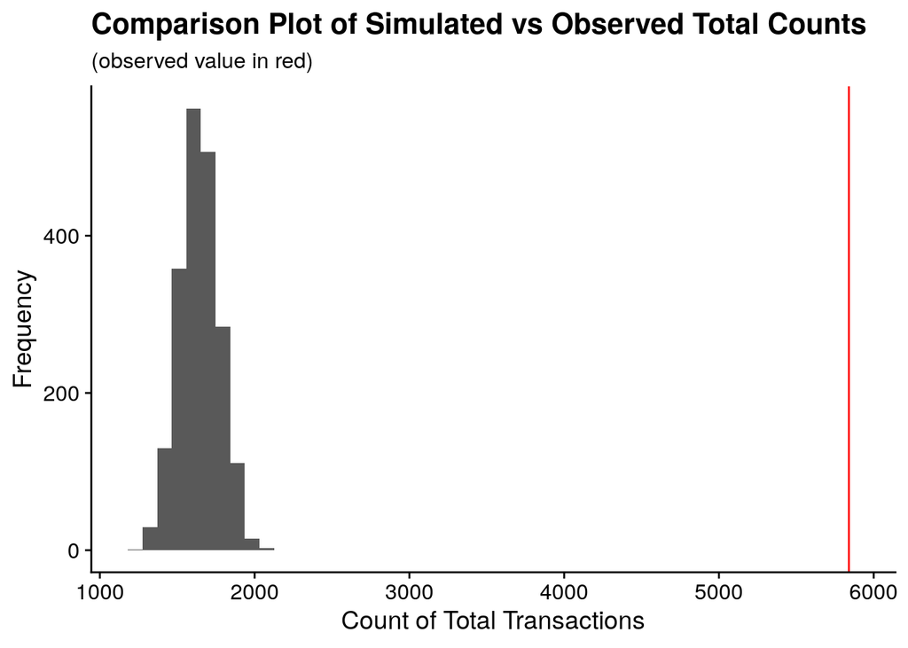

```r
obs_total_count <- customer_valid_stats_tbl |>
  pull(tnx_count) |>
  sum()

sim_data_tbl <- pnbd_init_valid_simstats_tbl |>
  count(draw_id, wt = sim_tnx_count, name = "sim_total_count")


ggplot(sim_data_tbl) +
  geom_histogram(aes(x = sim_total_count), bins = 50) +
  geom_vline(aes(xintercept = obs_total_count), colour = "red") +
  labs(
    x = "Count of Total Transactions",
    y = "Frequency",
    title = "Comparison Plot of Simulated vs Observed Total Counts",
    subtitle = "(observed value in red)"
    )
```

### 4.5.3 Transaction Count Quantiles

We now look at the quantiles for the transaction counts across each customer.

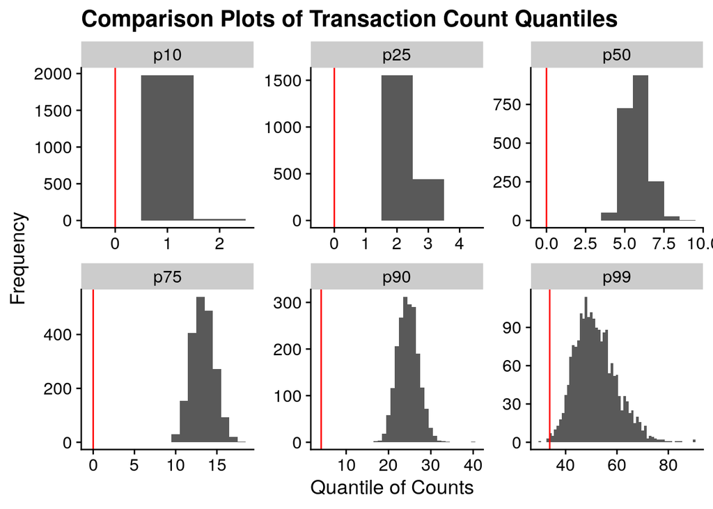

```r
obs_quantiles_tbl <- customer_valid_stats_tbl |>
  reframe(
    prob_label = c("p10", "p25", "p50", "p75", "p90", "p99"),
    prob_value = quantile(tnx_count, probs = c(0.10, 0.25, 0.50, 0.75, 0.90, 0.99))
    )

sim_data_tbl <- pnbd_init_valid_simstats_tbl |>
  filter(sim_tnx_count > 0) |>
  group_by(draw_id) |>
  summarise(
    p10 = quantile(sim_tnx_count, 0.10),
    p25 = quantile(sim_tnx_count, 0.25),
    p50 = quantile(sim_tnx_count, 0.50),
    p75 = quantile(sim_tnx_count, 0.75),
    p90 = quantile(sim_tnx_count, 0.90),
    p99 = quantile(sim_tnx_count, 0.99)
    ) |>
  pivot_longer(
    cols = !draw_id,
    names_to  = "prob_label",
    values_to = "sim_prob_values"
    ) |>
  inner_join(obs_quantiles_tbl, by = "prob_label")

ggplot(sim_data_tbl) +
  geom_histogram(aes(x = sim_prob_values), binwidth = 1) +
  geom_vline(aes(xintercept = prob_value), colour = "red") +
  facet_wrap(vars(prob_label), nrow = 2, scales = "free") +
  labs(
    x = "Quantile of Counts",
    y = "Frequency",
    title = "Comparison Plots of Transaction Count Quantiles"
    )
```

### 4.5.4 Check Overall Day-of-Week Transaction Patterns

We now want to check our assumption of each customer having a single rate of transaction frequency. This will manifest as a distribution of days of the week (and possibly months of the year), when contrasted with our simulations.

We will do this both by individual year and overall dataset.

```r
dow_props_valid_lst <- customer_valid_transactions_tbl |>
  calculate_dow_proportions()

tnx_valid_overall_dow_tbl   <- dow_props_valid_lst$overall
tnx_valid_yearmonth_dow_tbl <- dow_props_valid_lst$yearmonth


tnx_valid_overall_dow_tbl   |> glimpse()
```

```
Rows: 7
Columns: 3
$ dow_label <chr> "0-Sun", "1-Mon", "2-Tue", "3-Wed", "4-Thu", "5-Fri", "6-Sat"
$ obs_count <int> 242, 219, 238, 228, 246, 255, 252
$ obs_prop  <dbl> 0.1440476, 0.1303571, 0.1416667, 0.1357143, 0.1464286, 0.151…
```

```r
tnx_valid_yearmonth_dow_tbl |> glimpse()
```

```
Rows: 84
Columns: 4
$ yearmonth_date <date> 2022-01-01, 2022-01-01, 2022-01-01, 2022-01-01, 2022-0…
$ dow_label      <chr> "0-Sun", "1-Mon", "2-Tue", "3-Wed", "4-Thu", "5-Fri", "…
$ obs_count      <int> 33, 29, 39, 31, 26, 34, 31, 17, 17, 21, 29, 33, 22, 30,…
$ obs_prop       <dbl> 0.1479821, 0.1300448, 0.1748879, 0.1390135, 0.1165919, …
```

We now need to do the same thing for our simulations and then construct a comparison plot.

```r
sim_valid_tnxdata_tbl <- pnbd_init_valid_simstats_tbl |>
  select(customer_id, draw_id, sim_data) |>
  unnest(sim_data)

propdata_valid_tbl <- sim_valid_tnxdata_tbl |>
  group_nest(draw_id) |>
  mutate(
    prop_data = map(
      data, calculate_dow_proportions,

      .progress = "calculate_dow_propotions"
      ),
    overall_data   = map(prop_data, "overall"),
    yearmonth_data = map(prop_data, "yearmonth")
    )

propdata_valid_tbl |> glimpse()
```

```
Rows: 2,000
Columns: 5
$ draw_id        <int> 1, 2, 3, 4, 5, 6, 7, 8, 9, 10, 11, 12, 13, 14, 15, 16, …
$ data           <list<tibble[,3]>> [<tbl_df[1652 x 3]>], [<tbl_df[1612 x 3]>]…
$ prop_data      <list> [[<tbl_df[7 x 3]>], [<tbl_df[84 x 4]>]], [[<tbl_df[7 x…
$ overall_data   <list> [<tbl_df[7 x 3]>], [<tbl_df[7 x 3]>], [<tbl_df[7 x 3]>…
$ yearmonth_data <list> [<tbl_df[84 x 4]>], [<tbl_df[84 x 4]>], [<tbl_df[84 x …
```

We now want to compare the simulation data against the observed proportions.

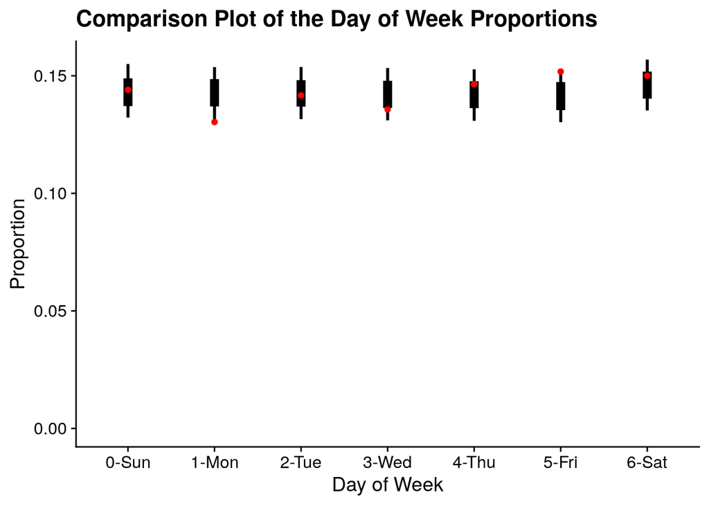

```r
simplot_valid_tbl <- propdata_valid_tbl |>
  select(draw_id, overall_data) |>
  unnest(overall_data) |>
  group_by(dow_label) |>
  summarise(
    .groups = "drop",

    p10 = quantile(obs_prop, 0.10),
    p25 = quantile(obs_prop, 0.25),
    p50 = quantile(obs_prop, 0.50),
    p75 = quantile(obs_prop, 0.75),
    p90 = quantile(obs_prop, 0.90)
    )

ggplot(simplot_valid_tbl) +
  geom_errorbar(
    aes(x = dow_label, ymin = p10, ymax = p90),
    width = 0, linewidth = 1
    ) +
  geom_errorbar(
    aes(x = dow_label, ymin = p25, ymax = p75),
    width = 0, linewidth = 3
    ) +
  geom_point(
    aes(x = dow_label, y = obs_prop),
    data = tnx_valid_overall_dow_tbl, colour = "red"
    ) +
  expand_limits(y = 0) +
  labs(
    x = "Day of Week",
    y = "Proportion",
    title = "Comparison Plot of the Day of Week Proportions"
    )
```

### 4.5.5 Check Monthly Day-of-Week Transaction Patterns

We now want to compare the plots for each of the days of week.

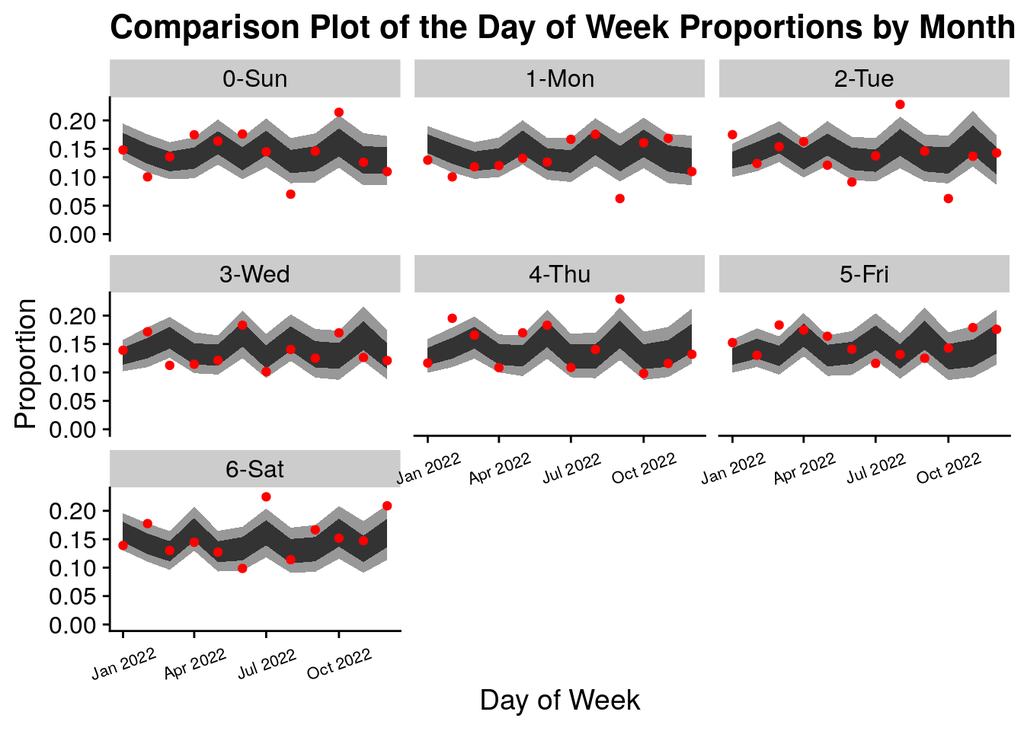

```r
simplot_valid_tbl <- propdata_valid_tbl |>
  select(draw_id, yearmonth_data) |>
  unnest(yearmonth_data) |>
  group_by(dow_label, yearmonth_date) |>
  summarise(
    .groups = "drop",

    p10 = quantile(obs_prop, 0.10),
    p25 = quantile(obs_prop, 0.25),
    p50 = quantile(obs_prop, 0.50),
    p75 = quantile(obs_prop, 0.75),
    p90 = quantile(obs_prop, 0.90)
    )

ggplot(simplot_valid_tbl) +
  geom_ribbon(
    aes(x = yearmonth_date, ymin = p10, ymax = p90),
    alpha = 0.5
    ) +
  geom_ribbon(
    aes(x = yearmonth_date, ymin = p25, ymax = p75),
    alpha = 1.0
    ) +
  geom_point(
    aes(x = yearmonth_date, y = obs_prop),
    data = tnx_valid_yearmonth_dow_tbl, colour = "red"
    ) +
  facet_wrap(vars(dow_label)) +
  expand_limits(y = 0) +
  labs(
    x = "Day of Week",
    y = "Proportion",
    title = "Comparison Plot of the Day of Week Proportions by Month"
    ) +
  theme(axis.text.x = element_text(angle = 20, size = 8, vjust = 0.5))
```

### 4.5.6 Write Data to Disk

We write this data to disk

```r
pnbd_init_valid_simstats_tbl |>
  write_rds("data/pnbd_init_assess_valid_simstats_tbl.rds", compress = "gz")
```

# 5 Fit Initial Transaction Amount Model

We now switch our attention to modelling the transaction amounts, and we do that by using a variation of what is known as the *Gamma/Gamma* model. This model can be built with a few different formulations, but the one we use assumes each transaction amount is independent and drawn from a Gamma distribution.

This distribution uses the mean/coefficient of variation parameterisation. All customer transaction use a fixed homogeneous coefficient of variation, but hereogeneity is distributed across the mean transaction amount for each customer, this mean being drawn from a hierarchical Gamma distribution with hierarchical mean and cov.

## 5.1 Compile and Fit Stan Model

As with the P/NBD model, we again start with the Stan model.

```
functions {
  #include util_functions.stan
}

data {
  int<lower=1> n_cust;                 // number of customers
  int<lower=1> n_tnx;                  // number of transaction amounts

  array[n_tnx] int<lower=1> cust_id;

  vector<lower=0>[n_tnx] amt;          // transaction amounts

  real<lower=0> custhier_mn;           // prior mean for lambda
  real<lower=0> custhier_cv;           // prior cv   for lambda

  real<lower=0> amt_cv;                // transaction amount cov
}

transformed data {
  real<lower=0> custhier_r     = 1 / (custhier_cv * custhier_cv);
  real<lower=0> custhier_alpha = 1 / (custhier_cv * custhier_cv * custhier_mn);

  real<lower=0> amt_r = 1 / (amt_cv * amt_cv);
}


parameters {
  vector<lower=0>[n_cust] amt_mn;     // customer tnx amount mean
}


transformed parameters {
  vector<lower=0>[n_cust] amt_alpha = 1 / (amt_cv * amt_cv * amt_mn);
}


model {
  // setting priors
  amt_mn ~ gamma(custhier_r, custhier_alpha);

  for(i in 1:n_tnx) {
    amt[i] ~ gamma(amt_r, amt_alpha[cust_id[i]]);
  }
}
```

We now compile this model using `CmdStanR`.

```r
tnxamt_fixed_stanmodel <- cmdstan_model(
  "stan_code/tnxamt_fixed.stan",
  include_paths =   stan_codedir,
  pedantic      =           TRUE,
  dir           =  stan_modeldir
  )
```

We then use this compiled model with our data to produce a fit of the data.

```r
stan_modelname <- "tnxamt_init"
stanfit_prefix <- str_c("fit_", stan_modelname)
stanfit_seed   <- stanfit_seed + 1

stanfit_object_file <- glue("data/{stanfit_prefix}_stanfit.rds")


stan_data_lst <- customer_fitdata_transactions_tbl |>
  transmute(customer_id, amt = tnx_amount) |>
  compose_data(

    custhier_mn = 100.00,
    custhier_cv =   1.00,

    amt_cv      =   1.00
    )

stan_data_lst$n_tnx   <- stan_data_lst$n
stan_data_lst$n_cust  <- stan_data_lst$n_customer_id
stan_data_lst$cust_id <- stan_data_lst$customer_id


if(!file_exists(stanfit_object_file)) {
  tnxamt_init_stanfit <- tnxamt_fixed_stanmodel$sample(
    data            =                stan_data_lst,
    chains          =                            4,
    iter_warmup     =                          500,
    iter_sampling   =                          500,
    seed            =                 stanfit_seed,
    adapt_delta     =                         0.95,
    save_warmup     =                        FALSE,
    output_dir      =                stan_modeldir,
    output_basename =               stanfit_prefix,
    )

  tnxamt_init_stanfit$save_object(stanfit_object_file, compress = "gzip")

} else {
  tnxamt_init_stanfit <- read_rds(stanfit_object_file)
}
```

```
Running MCMC with 4 chains, at most 12 in parallel...

Chain 1 Iteration:   1 / 1000 [  0%]  (Warmup)
Chain 2 Iteration:   1 / 1000 [  0%]  (Warmup)
Chain 3 Iteration:   1 / 1000 [  0%]  (Warmup)
Chain 4 Iteration:   1 / 1000 [  0%]  (Warmup)
Chain 4 Iteration: 100 / 1000 [ 10%]  (Warmup)
Chain 1 Iteration: 100 / 1000 [ 10%]  (Warmup)
Chain 3 Iteration: 100 / 1000 [ 10%]  (Warmup)
Chain 4 Iteration: 200 / 1000 [ 20%]  (Warmup)
Chain 2 Iteration: 100 / 1000 [ 10%]  (Warmup)
Chain 1 Iteration: 200 / 1000 [ 20%]  (Warmup)
Chain 3 Iteration: 200 / 1000 [ 20%]  (Warmup)
Chain 4 Iteration: 300 / 1000 [ 30%]  (Warmup)
Chain 2 Iteration: 200 / 1000 [ 20%]  (Warmup)
Chain 1 Iteration: 300 / 1000 [ 30%]  (Warmup)
Chain 3 Iteration: 300 / 1000 [ 30%]  (Warmup)
Chain 4 Iteration: 400 / 1000 [ 40%]  (Warmup)
Chain 2 Iteration: 300 / 1000 [ 30%]  (Warmup)
Chain 3 Iteration: 400 / 1000 [ 40%]  (Warmup)
Chain 1 Iteration: 400 / 1000 [ 40%]  (Warmup)
Chain 4 Iteration: 500 / 1000 [ 50%]  (Warmup)
Chain 4 Iteration: 501 / 1000 [ 50%]  (Sampling)
Chain 2 Iteration: 400 / 1000 [ 40%]  (Warmup)
Chain 3 Iteration: 500 / 1000 [ 50%]  (Warmup)
Chain 3 Iteration: 501 / 1000 [ 50%]  (Sampling)
Chain 4 Iteration: 600 / 1000 [ 60%]  (Sampling)
Chain 1 Iteration: 500 / 1000 [ 50%]  (Warmup)
Chain 1 Iteration: 501 / 1000 [ 50%]  (Sampling)
Chain 2 Iteration: 500 / 1000 [ 50%]  (Warmup)
Chain 2 Iteration: 501 / 1000 [ 50%]  (Sampling)
Chain 3 Iteration: 600 / 1000 [ 60%]  (Sampling)
Chain 4 Iteration: 700 / 1000 [ 70%]  (Sampling)
Chain 1 Iteration: 600 / 1000 [ 60%]  (Sampling)
Chain 2 Iteration: 600 / 1000 [ 60%]  (Sampling)
Chain 3 Iteration: 700 / 1000 [ 70%]  (Sampling)
Chain 4 Iteration: 800 / 1000 [ 80%]  (Sampling)
Chain 2 Iteration: 700 / 1000 [ 70%]  (Sampling)
Chain 1 Iteration: 700 / 1000 [ 70%]  (Sampling)
Chain 3 Iteration: 800 / 1000 [ 80%]  (Sampling)
Chain 4 Iteration: 900 / 1000 [ 90%]  (Sampling)
Chain 2 Iteration: 800 / 1000 [ 80%]  (Sampling)
Chain 1 Iteration: 800 / 1000 [ 80%]  (Sampling)
Chain 3 Iteration: 900 / 1000 [ 90%]  (Sampling)
Chain 4 Iteration: 1000 / 1000 [100%]  (Sampling)
Chain 4 finished in 216.4 seconds.
Chain 2 Iteration: 900 / 1000 [ 90%]  (Sampling)
Chain 1 Iteration: 900 / 1000 [ 90%]  (Sampling)
Chain 3 Iteration: 1000 / 1000 [100%]  (Sampling)
Chain 3 finished in 233.4 seconds.
Chain 2 Iteration: 1000 / 1000 [100%]  (Sampling)
Chain 2 finished in 240.0 seconds.
Chain 1 Iteration: 1000 / 1000 [100%]  (Sampling)
Chain 1 finished in 243.9 seconds.

All 4 chains finished successfully.
Mean chain execution time: 233.4 seconds.
Total execution time: 244.2 seconds.
```

```r
tnxamt_init_stanfit$print()
```

```
  variable      mean    median    sd   mad        q5       q95 rhat ess_bulk
 lp__      -91067.62 -91066.60 52.42 51.74 -91154.71 -90981.99 1.01      627
 amt_mn[1]    114.33    104.95 47.45 41.29     56.70    204.35 1.00     3602
 amt_mn[2]    168.70    146.21 95.46 80.49     58.81    351.55 1.00     5006
 amt_mn[3]    250.94    233.59 94.39 79.83    132.79    427.25 1.00     5204
 amt_mn[4]    130.43    106.18 90.24 66.82     36.95    305.68 1.00     4328
 amt_mn[5]    137.95    113.87 90.88 68.73     40.29    319.86 1.00     4956
 amt_mn[6]    231.47    217.61 84.06 72.94    125.34    386.99 1.00     5413
 amt_mn[7]    100.98     80.62 71.39 48.91     29.94    241.79 1.00     5528
 amt_mn[8]    156.12    143.17 65.63 54.94     77.08    277.71 1.01     5670
 amt_mn[9]    135.81    123.04 57.14 45.23     67.70    250.24 1.01     5306
 ess_tail
     1120
     1525
     1380
     1470
     1469
     1590
     1409
     1299
     1469
     1481

 # showing 10 of 10001 rows (change via 'max_rows' argument or 'cmdstanr_max_rows' option)
```

We have some basic HMC-based validity statistics we can check.

```r
tnxamt_init_stanfit$cmdstan_diagnose()
```

```
Processing csv files: /home/rstudio/btydwork/stan_models/fit_tnxamt_init-1.csv, /home/rstudio/btydwork/stan_models/fit_tnxamt_init-2.csv, /home/rstudio/btydwork/stan_models/fit_tnxamt_init-3.csv, /home/rstudio/btydwork/stan_models/fit_tnxamt_init-4.csv

Checking sampler transitions treedepth.
Treedepth satisfactory for all transitions.

Checking sampler transitions for divergences.
No divergent transitions found.

Checking E-BFMI - sampler transitions HMC potential energy.
E-BFMI satisfactory.

Effective sample size satisfactory.

Split R-hat values satisfactory all parameters.

Processing complete, no problems detected.
```

## 5.2 Visual Diagnostics of Sample Validity

Now that we have a sample from the posterior distribution we need to create a few different visualisations of the diagnostics.

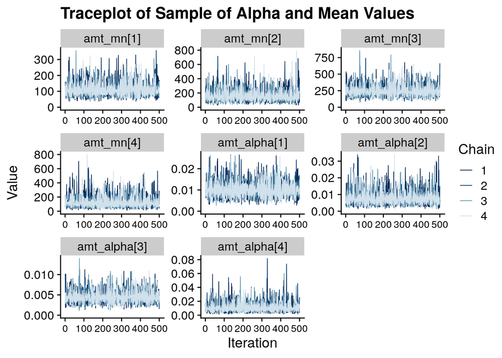

```r
parameter_subset <- c(
  "amt_mn[1]", "amt_mn[2]", "amt_mn[3]", "amt_mn[4]",
  "amt_alpha[1]",     "amt_alpha[2]",     "amt_alpha[3]",     "amt_alpha[4]"
  )

tnxamt_init_stanfit$draws() |>
  mcmc_trace(pars = parameter_subset) +
  expand_limits(y = 0) +
  labs(
    x = "Iteration",
    y = "Value",
    title = "Traceplot of Sample of Alpha and Mean Values"
    ) +
  theme(axis.text.x = element_text(size = 10))
```

A common MCMC diagnostic is $\hat{R}$ - which is a measure of the ‘similarity’ of the chains.

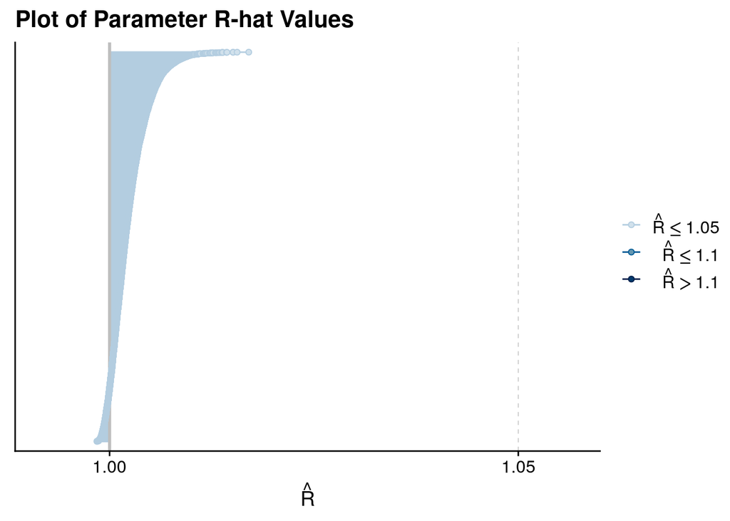

```r
tnxamt_init_stanfit |>
  rhat(pars = c("amt_mn", "amt_alpha")) |>
  mcmc_rhat() +
    ggtitle("Plot of Parameter R-hat Values")
```

Related to this quantity is the concept of *effective sample size*, $N_{eff}$, an estimate of the size of the sample from a statistical information point of view.

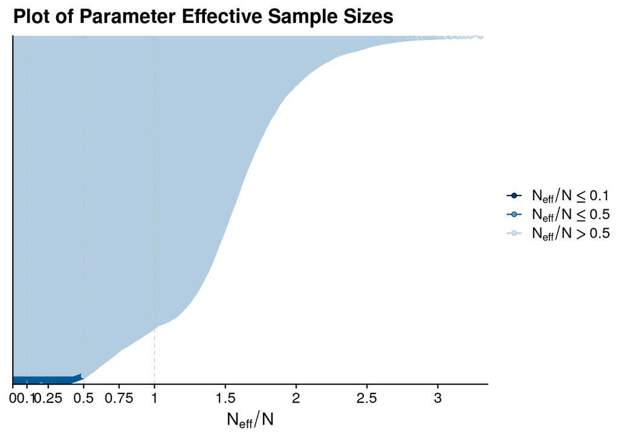

```r
tnxamt_init_stanfit |>
  neff_ratio(pars = c("amt_mn", "amt_alpha")) |>
  mcmc_neff() +
    ggtitle("Plot of Parameter Effective Sample Sizes")
```

Finally, we also want to look at autocorrelation in the chains for each parameter.

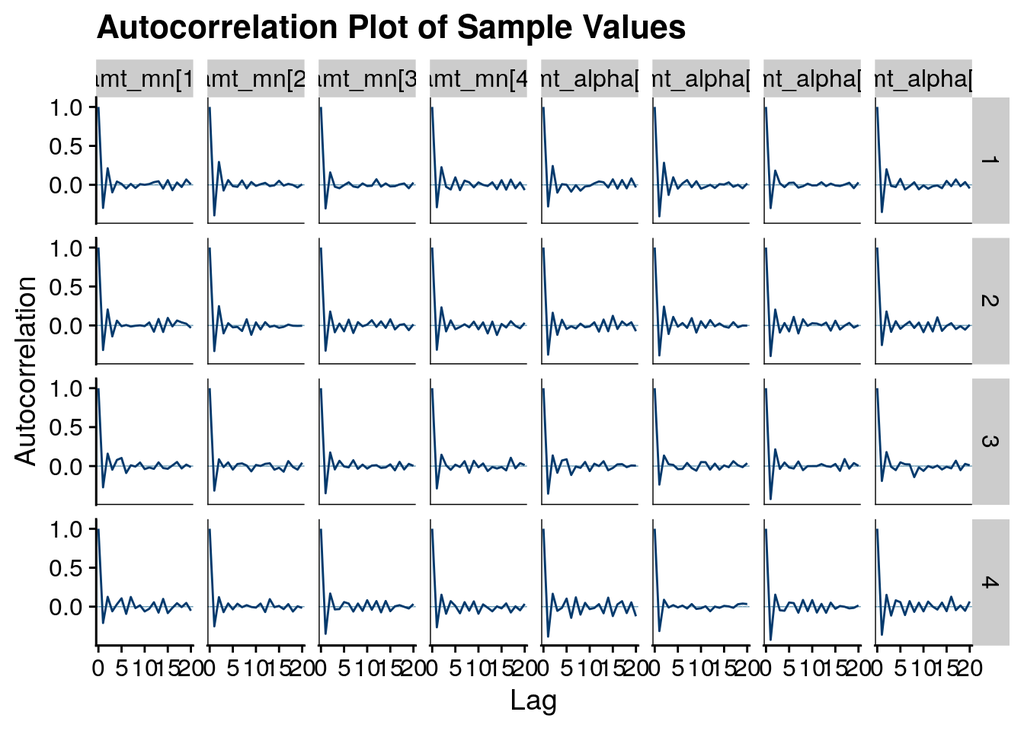

```r
tnxamt_init_stanfit$draws() |>
  mcmc_acf(pars = parameter_subset) +
    ggtitle("Autocorrelation Plot of Sample Values")
```

## 5.3 Check the Model Fit

```r
tnxamt_init_stanfit <- tnxamt_init_stanfit |>
  recover_types(customer_fitdata_transactions_tbl)
```

# R Environment

```r
options(width = 120L)
```

```r
options(width = 80L)
```